# Association Rules in Groceries

Janina Smoła

27/05/2018

# 1 WSTĘP

**OPIS POSTAWIONEGO ZADANIA**

Właściciel sklepu wielobranżowego postanowił zysk zainwestować w rozwój; zaplanowano powiększenie powierzchni użytkowej sklepu oraz lekką rearanżacje. Wychodząc naprzeciw potrzebom klientów rozwijane miałyby być działy/grupy produktów cieszące się największym zainteresowaniem, a o ich lokalizacji w obrębie nowej powierzchni zadecydować miała zasada maksymalizacji ewentualnych zakupów (możliwość zakupów impulsowych).

Wybór działów/grup produktów do rozwoju i ewentualny ich układ bazować ma na analizie list zakupów (najpopularniejsze), natomiast ich wzajemną lokalizację określić miałyby najciekwasze/ najsilniejsze reguły asocjacyjne. Na podstawie liczby transakcji w wykorzystywanym zbiorze zakłada się, że sklep ma rozmiary marketu osiedlowego - 9835 transakcji z okresu 1 miesiąca tj. ok. 30 transakcji na godzinę, przy 12-godzinnym dniu pracy i 7-dniowym tygodniu pracy.

**CELE GŁÓWNE EKSPERYMENTU**

1. wybór interesujących reguł (definicja na bazie dostępnych parametrów reguł);
2. wybór reguły najlepszej;
3. znalezienie praktycznych zastosować odkrytych reguł.

Przy opracowaniu zadania wykorzystano artykuły:

- https://cran.r-project.org/web/packages/arulesViz/vignettes/arulesViz.pdf
- https://cran.r-project.org/web/packages/arules/vignettes/arules.pdf
- http://r-statistics.co/Association-Mining-With-R.html

**UWAGA** komentarze są w jezyku polski, za wyjątkiem tytułów rysunków, które są w języku angielskim - tak jak wykorzystywana baza.

# 2 EKSPERYMENT - ELEMENTY CZĘSTE

## 2.1 Źrodło - zbiór *Groceries*, lista produktów i charakterystyka bazy

Ładowanie danych

```r
data(Groceries)
typeof(Groceries)
```

```
## [1] "S4"
```

```r
class(Groceries)
```

```
## [1] "transactions"
## attr(,"package")
## [1] "arules"
```

Rozmiar zbioru

```r
dim(Groceries)
```

```
## [1] 9835  169
```

Wszytkie produktu w zbiorze transaksyjnym

```r
itemLabels(Groceries)
```

```
##   [1] "frankfurter"               "sausage"
##   [3] "liver loaf"                "ham"
##   [5] "meat"                      "finished products"
##   [7] "organic sausage"           "chicken"
##   [9] "turkey"                    "pork"
##  [11] "beef"                      "hamburger meat"
##  [13] "fish"                      "citrus fruit"
##  [15] "tropical fruit"            "pip fruit"
##  [17] "grapes"                    "berries"
##  [19] "nuts/prunes"               "root vegetables"
##  [21] "onions"                    "herbs"
##  [23] "other vegetables"          "packaged fruit/vegetables"
##  [25] "whole milk"                "butter"
##  [27] "curd"                      "dessert"
##  [29] "butter milk"               "yogurt"
```

[output cut: 70 more lines]

Opis zbioru

```r
summary(Groceries)
```

```
## transactions as itemMatrix in sparse format with
##  9835 rows (elements/itemsets/transactions) and
##  169 columns (items) and a density of 0.02609146
##
## most frequent items:
##       whole milk other vegetables       rolls/buns             soda
##             2513             1903             1809             1715
##           yogurt          (Other)
##             1372            34055
##
## element (itemset/transaction) length distribution:
## sizes
##    1    2    3    4    5    6    7    8    9   10   11   12   13   14   15   16
## 2159 1643 1299 1005  855  645  545  438  350  246  182  117   78   77   55   46
##   17   18   19   20   21   22   23   24   26   27   28   29   32
##   29   14   14    9   11    4    6    1    1    1    1    3    1
##
##    Min. 1st Qu.  Median    Mean 3rd Qu.    Max.
##   1.000   2.000   3.000   4.409   6.000  32.000
##
## includes extended item information - examples:
##        labels  level2           level1
## 1 frankfurter sausage meat and sausage
## 2     sausage sausage meat and sausage
## 3  liver loaf sausage meat and sausage
```

Przykładowe transakcje

```r
inspect(head(Groceries, 3)); inspect(tail(Groceries, 3))
```

```
##     items
## [1] {citrus fruit,
##      semi-finished bread,
##      margarine,
##      ready soups}
## [2] {tropical fruit,
##      yogurt,
##      coffee}
## [3] {whole milk}
```

```
##     items
## [1] {chicken,
##      citrus fruit,
##      other vegetables,
##      butter,
##      yogurt,
##      frozen dessert,
##      domestic eggs,
##      rolls/buns,
##      rum,
##      cling film/bags}
## [2] {semi-finished bread,
##      bottled water,
##      soda,
##      bottled beer}
## [3] {chicken,
##      tropical fruit,
##      other vegetables,
##      vinegar,
##      shopping bags}
```

Rozmiar wektorów definiujących macierz rzadką zbioru danych *Groceries* ( *indices* definijące produkty oraz *pointers* - kolejny element macierzy rzadkiej)

```r
length(Groceries@data@i); length(Groceries@data@p)
```

```
## [1] 43367
```

```
## [1] 9836
```

Struktura zbior

```r
str(Groceries@itemInfo)
```

```
## 'data.frame':    169 obs. of  3 variables:
##  $ labels: chr  "frankfurter" "sausage" "liver loaf" "ham" ...
##  $ level2: Factor w/ 55 levels "baby food","bags",..: 44 44 44 44 44 44 44 42 42 41 ...
##  $ level1: Factor w/ 10 levels "canned food",..: 6 6 6 6 6 6 6 6 6 6 ...
```

Transakcje - liczba produktów

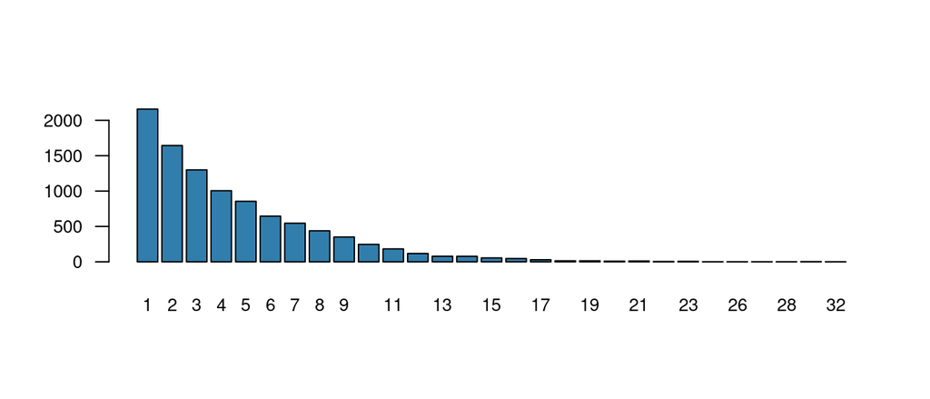

Size - number of products in each of transaction

```r
barplot(table(size(Groceries)), col = col_1, cex.axis = 0.8, cex.names = 0.8, las = 1)
```

Rozkład

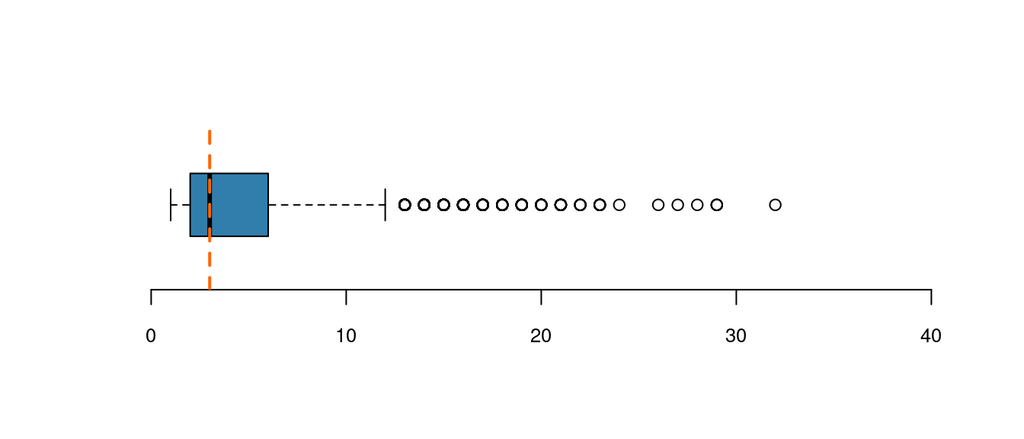

Size - number of products in each of transaction

```r
boxplot(size(Groceries), col = col_1, horizontal = TRUE, cex.axis = 0.8, cex.lab = 0.8,
        frame = FALSE, ylim = c(0, 40))
abline(v = 3, col = col_3, lwd = 2, lty = 2)
```

Macierz rzadka zbioru danych

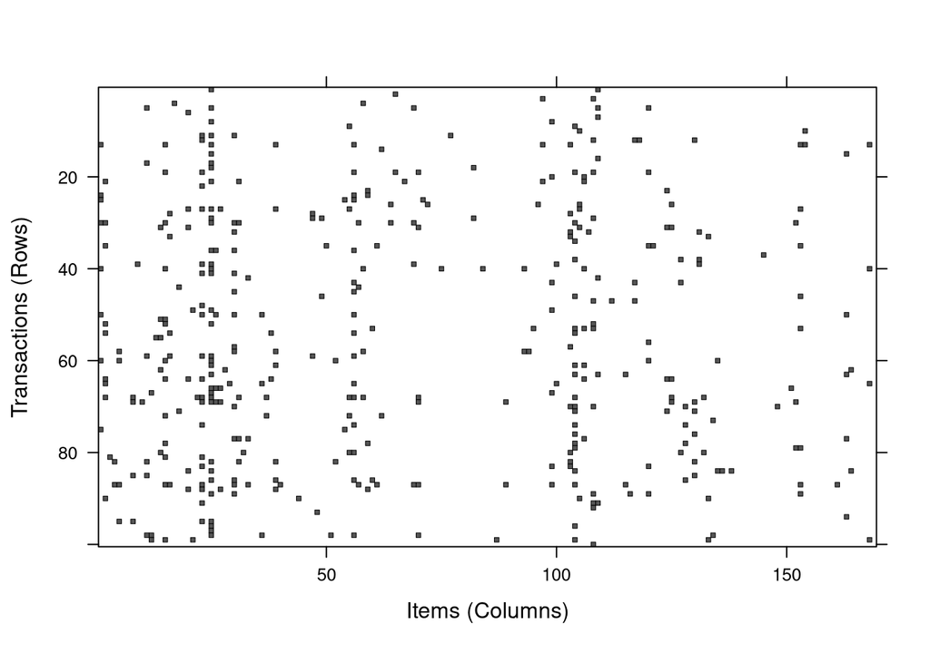

Image of spare matrix = transaction & products

```r
image(sample(Groceries, 100))
```

**PODSUMOWANIE - CHARAKTERYSTYKA BAZY DANYCH**

1. zbiór zawiera 9835 transakcji złożonych z 169 produktów;
2. zbiór danych jest raczej rzadki (gęstość - density of 0.02609146 -> 2,6%);
3. najczęściej występującym produktem jest ‘mleko’ ( *whole milk* - 2513), a następnie ‘inne warzywa’ ( *other vegetables* - 1903);
4. typowa transakcja (lista zakupów) zawiera mniej niż 5 produktów (średnia = 4.409) - mediana wynosi 3;
5. zbiór danych zawiera dodatkowe inforamcje o produktach - grupowanie produktów na dwóch poziomach, tj. *level 1* (10 elementów) i *level 2* (55 elementów).

## 2.2 Analiza listy produktów

Weryfikacja kompletności danych, liczebności działów i grup produktów.

```r
any(is.na(df_groc))
```

```
## [1] FALSE
```

```r
levels(df_groc$level1)
```

```
##  [1] "canned food"          "detergent"            "drinks"
##  [4] "fresh products"       "fruit and vegetables" "meat and sausage"
##  [7] "non-food"             "perfumery"            "processed food"
## [10] "snacks and candies"
```

Lista produktów przypisanych do poszczególnych grup produktowych ( *level 2* ):

```r
list_lvl2
```

```
## $`baby food`
## [1] "baby food"
##
## $bags
## [1] "shopping bags" "bags"
##
## $`bakery improver`
## [1] "baking powder"         "preservation products"
##
## $`bathroom cleaner`
## [1] "toilet cleaner"   "bathroom cleaner"
##
## $beef
## [1] "beef"           "hamburger meat"
##
## $beer
## [1] "bottled beer" "canned beer"
##
## $`bread and backed goods`
## [1] "rolls/buns"          "white bread"         "brown bread"
## [4] "pastry"              "roll products "      "semi-finished bread"
## [7] "zwieback"
##
## $candy
## [1] "candy"
##
## $`canned fish`
## [1] "canned fish"
##
## $`canned fruit/vegetables`
## [1] "canned vegetables"    "canned fruit"         "pickled vegetables"
## [4] "specialty vegetables"
##
## $cheese
## [1] "soft cheese"      "sliced cheese"    "hard cheese"      "cream cheese "
## [5] "processed cheese" "spread cheese"    "curd cheese"      "specialty cheese"
##
## $`chewing gum`
## [1] "chewing gum"
##
```

[output cut: 129 more lines]

```
##
## $sweetener
## [1] "sugar"            "artif. sweetener" "honey"
##
## $`tea/cocoa drinks`
## [1] "tea"          "cocoa drinks"
##
## $vegetables
## [1] "root vegetables"  "onions"           "herbs"            "other vegetables"
##
## $`vinegar/oils`
## [1] "vinegar"       "oil"           "margarine"     "specialty fat"
##
## $wine
## [1] "white wine"     "red/blush wine" "prosecco"       "sparkling wine"
```

Liczba produktów w grupie - ile grup ma okresloną liczbę produktów

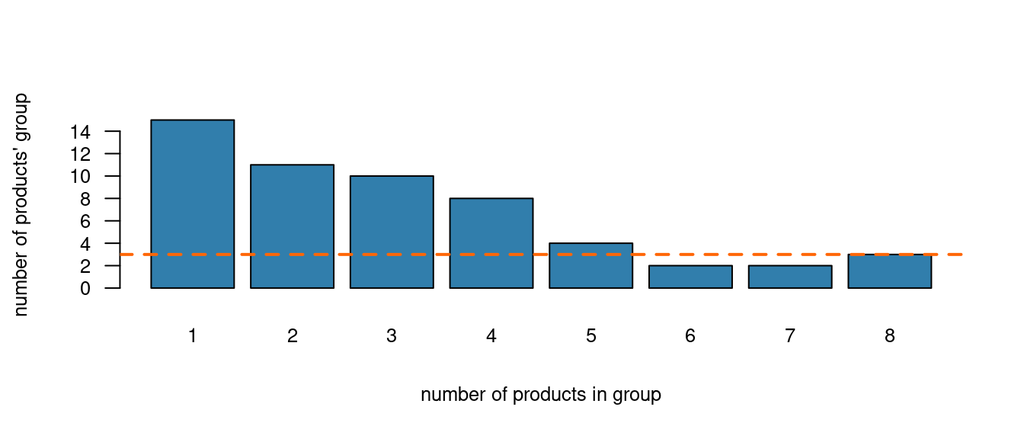

Number of items in each products’ group

```r
barplot(table(len_list_lvl2), col = col_1, cex.axis = 0.8, cex.names = 0.8, cex.lab = 0.8, las = 1,
        xlab = 'number of products in group', ylab = 'number of products\' group')
abline(h = 3, col = col_3, lwd = 2, lty = 2)
```

Transakcje wg produktów

```r
inspect(head(Groceries, 3))
```

```
##     items
## [1] {citrus fruit,
##      semi-finished bread,
##      margarine,
##      ready soups}
## [2] {tropical fruit,
##      yogurt,
##      coffee}
## [3] {whole milk}
```

Transakcje wg grup produktów (na *level 2* )

```r
inspect(head(Groceries_lvl2,3))
```

```
##     items
## [1] {bread and backed goods,
##      fruit,
##      soups/sauces,
##      vinegar/oils}
## [2] {coffee,
##      dairy produce,
##      fruit}
## [3] {dairy produce}
```

**PODSUMOWANIE DZIAŁY/ GRUPY TOWAROWE**

### 2.2.1 Wykresy dla produktów z bazy *Groceries*

20 produktów o najwyższym wsparciu względnym

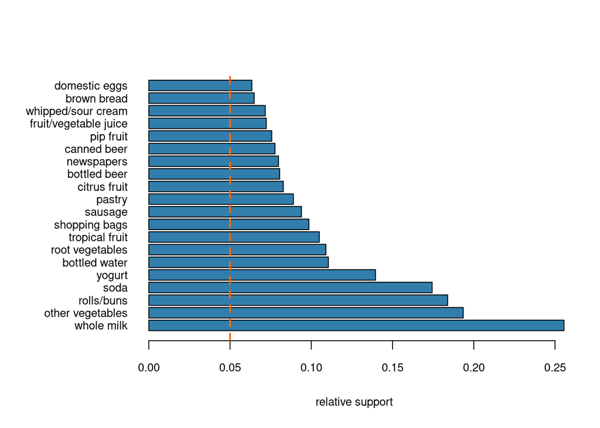

Plot of frequency for top 20 products

```r
itemFrequencyPlot(Groceries, topN = 20, col = col_1, horiz = TRUE,
                  xlab = 'relative support', cex = 0.8, cex.axis = 0.8, cex.lab = 0.8, las = 1)
abline(v = 0.05, col = col_3, lwd = 2, lty = 2)
```

Produkty, dla których min wsparcie względne wynosi 0.10

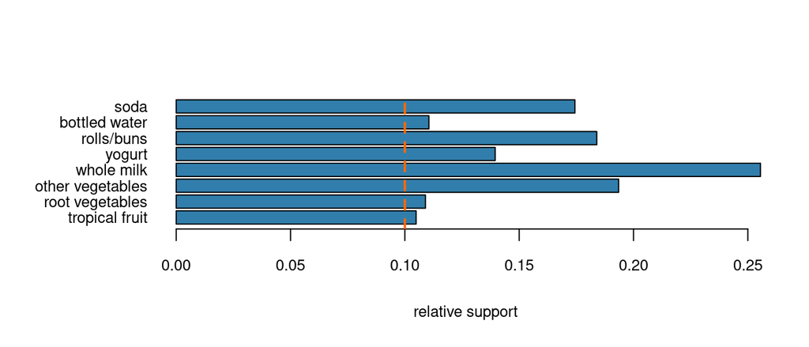

Plot of frequency for products with min support = 0.1

```r
itemFrequencyPlot(Groceries, support = 0.10, col = col_1, horiz = TRUE,
                  xlab = 'relative support', cex = 0.8, cex.axis = 0.8, cex.lab = 0.8, las = 1)
abline(v = 0.10, col = col_3, lwd = 2, lty = 2)
```

Produkty, dla których min wsparcie względne wynosi 0.05

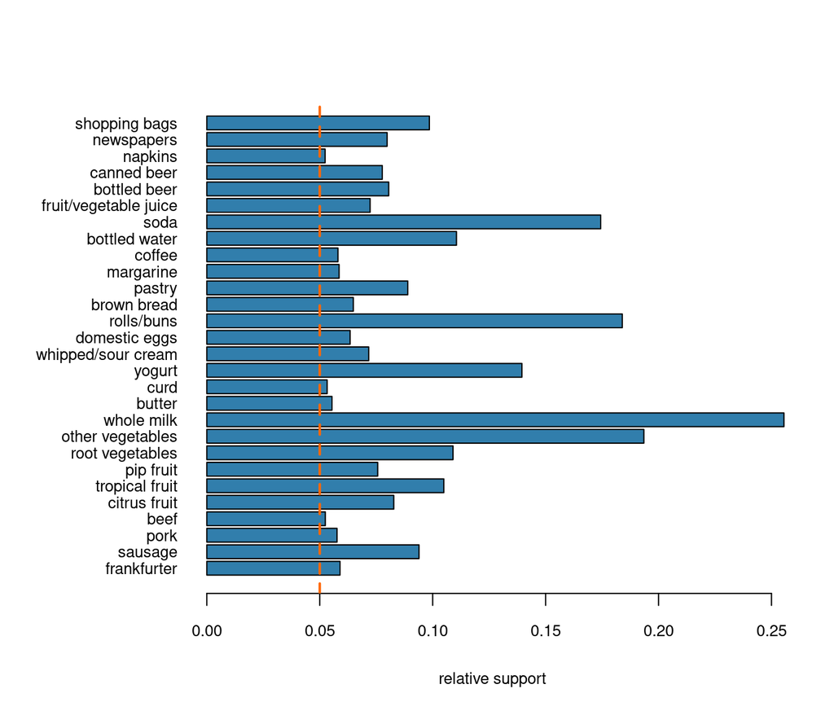

Plot of frequency for products with min support = 0.05

```r
itemFrequencyPlot(Groceries, support = 0.05, col = col_1, horiz = TRUE,
                  xlab = 'relative support', cex = 0.8, cex.axis = 0.8, cex.lab = 0.8, las = 1)
abline(v = 0.05, col = col_3, lwd = 2, lty = 2)
```

### 2.2.2 Wykresy dla grup produktów z bazy *Groceries* - level2

20 grup produktów o najwyższym wsparciu względnym

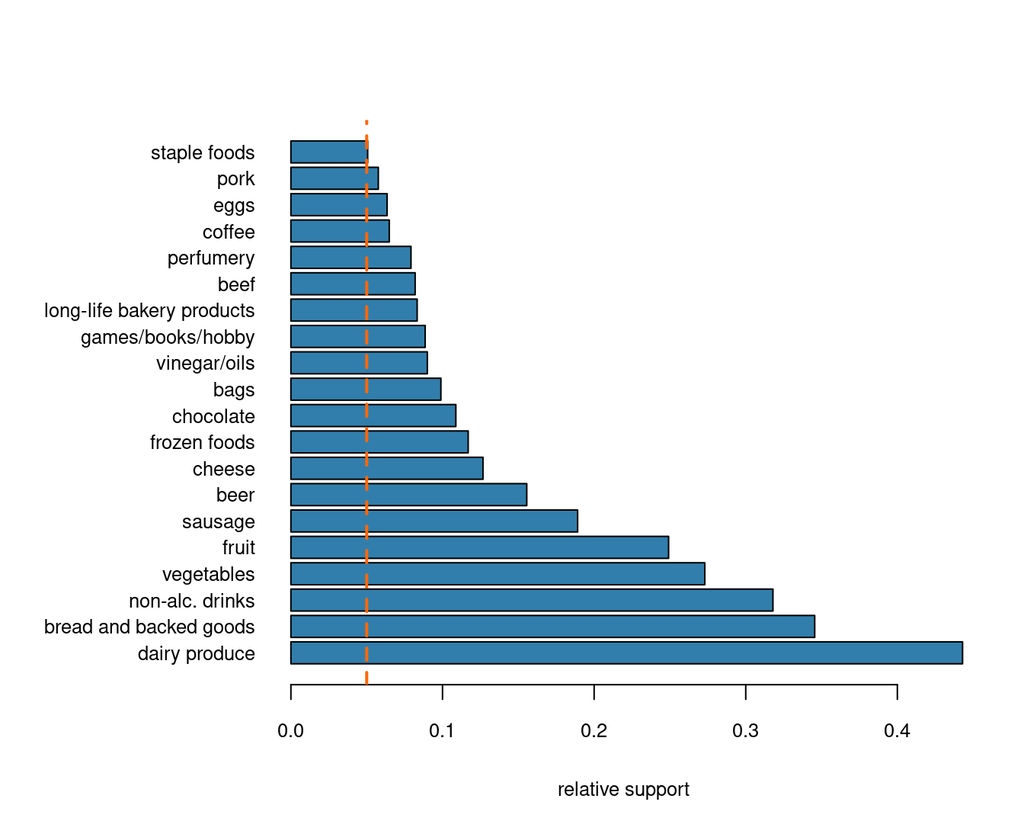

Plot of frequency for 20 top products’ groups

```r
itemFrequencyPlot(Groceries_lvl2, topN = 20, col = col_1, horiz = TRUE,
                  xlab = 'relative support', cex = 0.8, cex.axis = 0.8, cex.lab = 0.8, las = 1)
abline(v = 0.05, col = col_3, lwd = 2, lty = 2)
```

Produkty, dla których min wsparcie względne wynosi 0.10

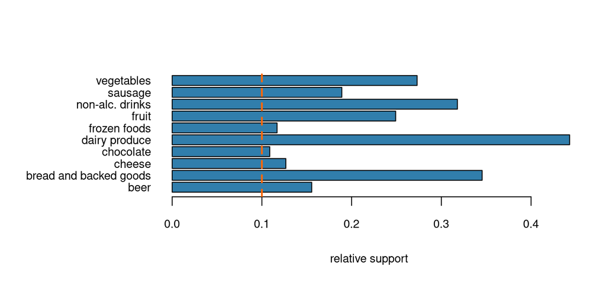

Plot of frequency for products’ groups with min support = 0.1

```r
itemFrequencyPlot(Groceries_lvl2, support = 0.10, col = col_1, horiz = TRUE,
                  xlab = 'relative support', cex = 0.8, cex.axis = 0.8, cex.lab = 0.8, las = 1)
abline(v = 0.10, col = col_3, lwd = 2, lty = 2)
```

Produkty, dla których min wsparcie względne wynosi 0.05

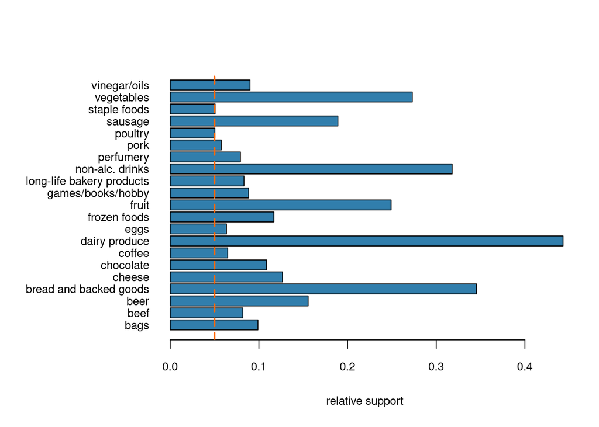

```r
itemFrequencyPlot(Groceries_lvl2, support = 0.05, col = col_1, horiz = TRUE,
                  xlab = 'relative support', cex = 0.8, cex.axis = 0.8, cex.lab = 0.8, las = 1)
abline(v = 0.05, col = col_3, lwd = 2, lty = 2)
```

### 2.2.3 Wsparcie i wsparcie względne poszczególnych produktów

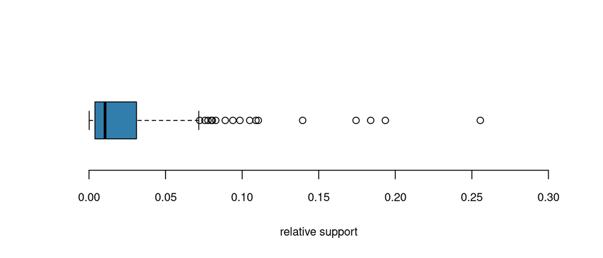

Relative support for each single product

```r
boxplot(tab_freq, horizontal = TRUE, col = col_1, xlab = 'relative support',
        cex.axis = 0.8, cex.lab = 0.8, frame = FALSE, ylim = c(0, 0.3))
```

Produkty o największym i najmniejszym wsparciu względnym

```r
head(tab_freq)
```

```
##       whole milk other vegetables       rolls/buns             soda
##        0.2555160        0.1934926        0.1839349        0.1743772
##           yogurt    bottled water
##        0.1395018        0.1105236
```

```r
tail(tab_freq)
```

```
##        baby cosmetics       kitchen utensil                  bags
##          0.0006100661          0.0004067107          0.0004067107
## preservation products             baby food  sound storage medium
##          0.0002033554          0.0001016777          0.0001016777
```

Wsparcie absolutne/bezwzględne produktu (liczebność transakcji z danym produktem)

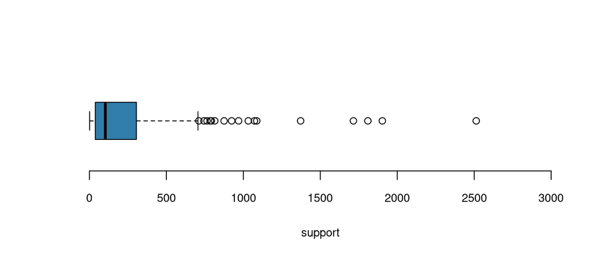

Support for each single product

```r
boxplot(tab_freq_ab, horizontal = TRUE, col = col_1, xlab = 'support',
        cex.axis = 0.8, cex.lab = 0.8, frame = FALSE, ylim = c(0, 3000))
```

**Propozycje elementów z *minSup***

- elementy=produkty ze wsparciem względnym > 20% (wsparcie bezwzględne: 1968 = 0.20 * 9835)

```r
length(tab_freq[tab_freq > 0.20]); print(tab_freq[tab_freq > 0.20])
```

```
## [1] 1
```

```
## whole milk
##   0.255516
```

- elementy=produkty ze wspaciem względnym >= 10% (wsparcie bezwzględne: 984 = 0.10 * 9835)

```r
length(tab_freq[tab_freq >= 0.1])
```

```
## [1] 8
```

```r
print(tab_freq[tab_freq >= 0.1])
```

```
##       whole milk other vegetables       rolls/buns             soda
##        0.2555160        0.1934926        0.1839349        0.1743772
##           yogurt    bottled water  root vegetables   tropical fruit
##        0.1395018        0.1105236        0.1089985        0.1049314
```

- elementy=produkty ze wspaciem względnym >= 5% (wsparcie bezwzględne: 490 = 0.05 * 9835)

```r
length(tab_freq[tab_freq >= 0.05]); print(tab_freq[tab_freq >= 0.05][1:5])
```

```
## [1] 28
```

```
##       whole milk other vegetables       rolls/buns             soda
##        0.2555160        0.1934926        0.1839349        0.1743772
##           yogurt
##        0.1395018
```

- liczba elementów ze wspaciem >= 100 (~>1%)

```r
length(tab_freq_ab[tab_freq_ab >= 100]); print(tab_freq_ab[tab_freq_ab >= 100][1:5])
```

```
## [1] 88
```

```
##       whole milk other vegetables       rolls/buns             soda
##             2513             1903             1809             1715
##           yogurt
##             1372
```

### 2.2.4 Produkty częste

Wybór produktów częstych przy założeniu wsparcia względnego na poziomie 10% (984 transakcje: *minSup* = 984, *minrSup* = 0.10)

```r
(list_pop_products <- names(tab_freq_ab[tab_freq_ab > 984]))
```

```
## [1] "whole milk"       "other vegetables" "rolls/buns"       "soda"
## [5] "yogurt"           "bottled water"    "root vegetables"  "tropical fruit"
```

Grupy, do którch należą najpopularniejsze produkty

```r
filter(itemInfo(Groceries), labels %in% list_pop_products) %>% select(level2) %>% unique()
```

```
##                   level2
## 1                  fruit
## 2             vegetables
## 4          dairy produce
## 6 bread and backed goods
## 7        non-alc. drinks
```

```r
filter(itemInfo(Groceries), labels %in% list_pop_products) %>% select(level2) %>% table() %>% as.data.frame() %>% filter(Freq != 0)
```

```
##                        . Freq
## 1 bread and backed goods    1
## 2          dairy produce    2
## 3                  fruit    1
## 4        non-alc. drinks    2
## 5             vegetables    2
```

**WNIOSKI**

Najczęsciej występujące produkty to: (= produkty częste o wsparciu większym od *minSup* = 984)

```r
list_pop_products
```

```
## [1] "whole milk"       "other vegetables" "rolls/buns"       "soda"
## [5] "yogurt"           "bottled water"    "root vegetables"  "tropical fruit"
```

Najczęściej występujące produkty należą do następujących grup produktów

| grupa produktów | produkty |
| --- | --- |
| bread and backed goods | 1 produkt, tj. “rolls/buns” |
| dairy produce | 2 produkt, tj. “whole milk” “yogurt” |
| fruit | 1 produkt, tj. “tropical fruit” |
| non-alc. drinks | 2 produkt, tj. “soda” “bottled water” |
| vegetables | 2 produkt, tj. “other vegetables” “root vegetables” |

**SPRAWDZENIE (obliczenie apriori dla częstych elementów=produktów)**

```r
list_pop_products_spr  <- apriori(data = Groceries, ## object of class transactions
                                  parameter = list(support = 0.003, confidence = 0.2,
                                                   target = 'frequent itemsets'))
```

```
## Apriori
##
## Parameter specification:
##  confidence minval smax arem  aval originalSupport maxtime support minlen
##          NA    0.1    1 none FALSE            TRUE       5   0.003      1
##  maxlen            target  ext
##      10 frequent itemsets TRUE
##
## Algorithmic control:
##  filter tree heap memopt load sort verbose
##     0.1 TRUE TRUE  FALSE TRUE    2    TRUE
##
## Absolute minimum support count: 29
##
## set item appearances ...[0 item(s)] done [0.00s].
## set transactions ...[169 item(s), 9835 transaction(s)] done [0.00s].
## sorting and recoding items ... [136 item(s)] done [0.00s].
## creating transaction tree ... done [0.00s].
## checking subsets of size 1 2 3 4 5 done [0.00s].
## sorting transactions ... done [0.00s].
## writing ... [2226 set(s)] done [0.00s].
## creating S4 object  ... done [0.00s].
```

```r
summary(list_pop_products_spr)
```

```
## set of 2226 itemsets
##
## most frequent items:
##       whole milk other vegetables           yogurt  root vegetables
##              556              468              316              251
##       rolls/buns          (Other)
##              241             3536
##
## element (itemset/transaction) length distribution:sizes
##    1    2    3    4    5
##  136 1140  850   98    2
##
##    Min. 1st Qu.  Median    Mean 3rd Qu.    Max.
##   1.000   2.000   2.000   2.412   3.000   5.000
##
## summary of quality measures:
##     support         transIdenticalToItemsets     count
##  Min.   :0.003050   Min.   :0.0000000        Min.   :  30.00
##  1st Qu.:0.003660   1st Qu.:0.0000000        1st Qu.:  36.00
##  Median :0.004779   Median :0.0000000        Median :  47.00
##  Mean   :0.007879   Mean   :0.0001613        Mean   :  77.49
##  3rd Qu.:0.007219   3rd Qu.:0.0001017        3rd Qu.:  71.00
##  Max.   :0.255516   Max.   :0.0265379        Max.   :2513.00
##
## includes transaction ID lists: FALSE
##
## mining info:
##       data ntransactions support confidence
##  Groceries          9835   0.003          1
```

```r
inspect(sort(subset(list_pop_products_spr, subset = count > 984)))
```

```
##     items              support   transIdenticalToItemsets count
## [1] {whole milk}       0.2555160 0.012506355              2513
## [2] {other vegetables} 0.1934926 0.006304016              1903
## [3] {rolls/buns}       0.1839349 0.011184545              1809
## [4] {soda}             0.1743772 0.016268429              1715
## [5] {yogurt}           0.1395018 0.004067107              1372
## [6] {bottled water}    0.1105236 0.006812405              1087
## [7] {root vegetables}  0.1089985 0.002541942              1072
## [8] {tropical fruit}   0.1049314 0.002338587              1032
```

A zatem przy zastosowaniu metody alternatywnej uzyskany został ten sam wynik.

### 2.2.5 Wsparcie i wsparcie względne grup produktów (level2)

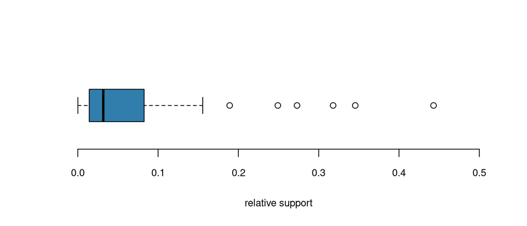

Relative support for each single products’ group

```r
boxplot(tab_freq_lvl2, horizontal = TRUE, col = col_1, xlab = 'relative support',
        cex.axis = 0.8, cex.lab = 0.8, frame = FALSE, ylim = c(0, 0.5))
```

Produkty o największym i najmniejszym wsparciu względnym

```r
head(tab_freq_lvl2)
```

```
##          dairy produce bread and backed goods        non-alc. drinks
##              0.4430097              0.3455008              0.3179461
##             vegetables                  fruit                sausage
##              0.2730046              0.2491103              0.1891205
```

```r
tail(tab_freq_lvl2)
```

```
##             fish             soap   pudding powder        hair care
##     0.0029486528     0.0026436197     0.0023385867     0.0011184545
## personal hygiene        baby food
##     0.0010167768     0.0001016777
```

Wsparcie absolutne/bezwzględne produktu (liczebność transakcji z danym produktem)

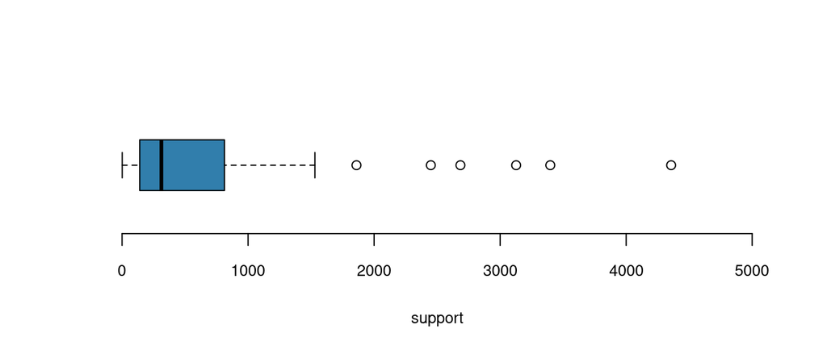

Support for each single products’ group

```r
boxplot(tab_freq_lvl2_ab, horizontal = TRUE, col = col_1, xlab = 'support',
        cex.axis = 0.8, cex.lab = 0.8, frame = FALSE, ylim = c(0, 5000))
```

**Propozycje elementów z *minSup***

- elementy=grupy produktów ze wsparciem względnym > 20% (wsparcie bezwzględne: 1968 = 0.20 * 9835)

```r
length(tab_freq_lvl2[tab_freq_lvl2 > 0.20]); print(tab_freq_lvl2[tab_freq_lvl2 > 0.20])
```

```
## [1] 5
```

```
##          dairy produce bread and backed goods        non-alc. drinks
##              0.4430097              0.3455008              0.3179461
##             vegetables                  fruit
##              0.2730046              0.2491103
```

- elementy=grupy produktów ze wspaciem względnym >= 10% (wsparcie bezwzględne: 984 = 0.10 * 9835)

```r
length(tab_freq_lvl2[tab_freq_lvl2 > 0.10]); print(tab_freq_lvl2[tab_freq_lvl2 > 0.10][1:5])
```

```
## [1] 10
```

```
##          dairy produce bread and backed goods        non-alc. drinks
##              0.4430097              0.3455008              0.3179461
##             vegetables                  fruit
##              0.2730046              0.2491103
```

- elementy=grupy produktów ze wspaciem względnym >= 5% (wsparcie bezwzględne: 490 = 0.05 * 9835)

```r
length(tab_freq_lvl2[tab_freq_lvl2 >= 0.05]); print(tab_freq_lvl2[tab_freq_lvl2 >= 0.05][1:5])
```

```
## [1] 21
```

```
##          dairy produce bread and backed goods        non-alc. drinks
##              0.4430097              0.3455008              0.3179461
##             vegetables                  fruit
##              0.2730046              0.2491103
```

- liczba elementów=grup produktów ze wspaciem >= 100 (~>1%)

```r
length(tab_freq_lvl2_ab[tab_freq_lvl2_ab >= 100]); print(tab_freq_lvl2_ab[tab_freq_lvl2_ab >= 100][1:5])
```

```
## [1] 44
```

```
##          dairy produce bread and backed goods        non-alc. drinks
##                   4357                   3398                   3127
##             vegetables                  fruit
##                   2685                   2450
```

### 2.2.6 Grupy produktów częste (level2)

Wybór grup produktów częstych przy założeniu wsparcia względnego na poziomie 10% (984 transakcje: *minSup* = 984, *minrSup* = 0.10)

```r
(list_pop_gr_products <- names(sort(tab_freq_lvl2_ab[tab_freq_lvl2_ab > 984], decreasing = TRUE)))
```

```
##  [1] "dairy produce"          "bread and backed goods" "non-alc. drinks"
##  [4] "vegetables"             "fruit"                  "sausage"
##  [7] "beer"                   "cheese"                 "frozen foods"
## [10] "chocolate"
```

**Wnioski**

Najczęsciej występujące grupy prduktów to:

1. Produkty z grupy produkty mleczne występują w 4357 z 9835 transakcji (44,3%);
2. produkty z grupy pieczywo i wypieki - w 3398 z 9835 transakcji (34,5%);
3. produkty z grupy napoje niealkoholowe - 3127 z 9835 transakcji (31,8%);
4. produkty z grupy warzywa - 2685 z 9835 transakcji (27,3%);
5. produkty z grupy owoce - 2450 z 9835 transakcji (24,9%).

**SPRAWDZENIE (obliczenie apriori dla częstych elementów=grupy produkótw)**

```r
list_pop_gr_products_spr  <- apriori(data = Groceries_lvl2, ## object of class transactions
                                     parameter = list(support = 0.003, confidence = 0.2, # zmienione na 1
                                                      target = 'frequent itemsets'))
```

```
## Apriori
##
## Parameter specification:
##  confidence minval smax arem  aval originalSupport maxtime support minlen
##          NA    0.1    1 none FALSE            TRUE       5   0.003      1
##  maxlen            target  ext
##      10 frequent itemsets TRUE
##
## Algorithmic control:
##  filter tree heap memopt load sort verbose
##     0.1 TRUE TRUE  FALSE TRUE    2    TRUE
##
## Absolute minimum support count: 29
##
## set item appearances ...[0 item(s)] done [0.00s].
## set transactions ...[55 item(s), 9835 transaction(s)] done [0.00s].
## sorting and recoding items ... [49 item(s)] done [0.00s].
## creating transaction tree ... done [0.00s].
## checking subsets of size 1 2 3 4 5 6 7 done [0.01s].
## sorting transactions ... done [0.00s].
## writing ... [3496 set(s)] done [0.00s].
## creating S4 object  ... done [0.00s].
```

```r
summary(list_pop_gr_products_spr)
```

```
## set of 3496 itemsets
##
## most frequent items:
##          dairy produce bread and backed goods             vegetables
##                   1457                   1141                   1109
##                  fruit        non-alc. drinks                (Other)
##                   1042                    990                   6266
##
## element (itemset/transaction) length distribution:sizes
##    1    2    3    4    5    6    7
##   49  532 1306 1131  419   58    1
##
##    Min. 1st Qu.  Median    Mean 3rd Qu.    Max.
##   1.000   3.000   3.000   3.434   4.000   7.000
##
## summary of quality measures:
##     support         transIdenticalToItemsets     count
##  Min.   :0.003050   Min.   :0.0000000        Min.   :  30.00
##  1st Qu.:0.003660   1st Qu.:0.0000000        1st Qu.:  36.00
##  Median :0.004881   Median :0.0000000        Median :  48.00
##  Mean   :0.008855   Mean   :0.0001676        Mean   :  87.09
##  3rd Qu.:0.007931   3rd Qu.:0.0001017        3rd Qu.:  78.00
##  Max.   :0.443010   Max.   :0.0389425        Max.   :4357.00
##
## includes transaction ID lists: FALSE
##
## mining info:
##            data ntransactions support confidence
##  Groceries_lvl2          9835   0.003          1
```

```r
inspect(sort(subset(list_pop_gr_products_spr, subset = count > 984)))
```

```
##      items                                    support
## [1]  {dairy produce}                          0.4430097
## [2]  {bread and backed goods}                 0.3455008
## [3]  {non-alc. drinks}                        0.3179461
## [4]  {vegetables}                             0.2730046
## [5]  {fruit}                                  0.2491103
## [6]  {sausage}                                0.1891205
## [7]  {bread and backed goods,dairy produce}   0.1876970
## [8]  {dairy produce,vegetables}               0.1704118
## [9]  {dairy produce,fruit}                    0.1563803
## [10] {beer}                                   0.1555669
## [11] {dairy produce,non-alc. drinks}          0.1519065
## [12] {cheese}                                 0.1266904
## [13] {bread and backed goods,non-alc. drinks} 0.1242501
## [14] {frozen foods}                           0.1169293
```

[output cut: 27 more lines]

Potwierdza to wcześniejsze wyniki - otrzymano tą samą listę najczęstszych grup produktowych.

### 2.2.7 Częste produkty i częste grupy

Analiza, które produkty są częste i z jakich grup produktów występ, mających największe wsparcie (>30% transakcji, tzn. dla trzech pierwszych)

1. grup ‘produkty mleczne’ ( *dairy produce* ) - produkty:

```r
(items_lvl2_1 <- list_lvl2$`dairy produce`)
```

```
## [1] "whole milk"         "butter"             "curd"
## [4] "dessert"            "butter milk"        "yogurt"
## [7] "whipped/sour cream" "beverages"
```

Wsparcie produktów

```r
(gr_prod_1 <- sort(tab_freq[items_lvl2_1], decreasing = TRUE))
```

```
##         whole milk             yogurt whipped/sour cream             butter
##         0.25551601         0.13950178         0.07168277         0.05541434
##               curd            dessert        butter milk          beverages
##         0.05327911         0.03711235         0.02796136         0.02602949
```

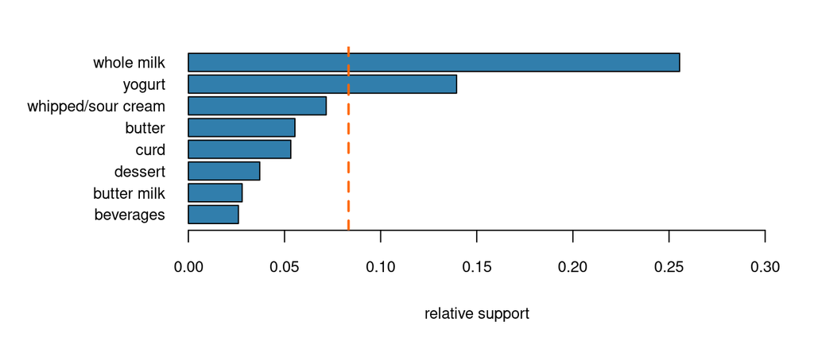

Relative support for products from ‘dairy produce’ group

```r
par(mar= c(5.1, 8.1, 2, 2.1))
barplot(rev(gr_prod_1), horiz = TRUE, col = col_1, las = 1, xlim = c(0, 0.3),
       xlab = 'relative support', ylab = '', cex.axis = 0.8, cex.lab = 0.8, cex.names = 0.8)
abline(v = mean(gr_prod_1), col = col_3, lwd = 2, lty = 2)
```

2. grupa ‘chleb i wypieki’ ( *bread and backed goods* ) - produkty:

```r
(items_lvl2_2 <- list_lvl2$`bread and backed goods`)
```

```
## [1] "rolls/buns"          "white bread"         "brown bread"
## [4] "pastry"              "roll products "      "semi-finished bread"
## [7] "zwieback"
```

Wsparcie produktów

```r
(gr_prod_2 <- sort(tab_freq[items_lvl2_2], decreasing = TRUE))
```

```
##          rolls/buns              pastry         brown bread         white bread
##         0.183934926         0.088967972         0.064870361         0.042094560
## semi-finished bread      roll products             zwieback
##         0.017691917         0.010269446         0.006914082
```

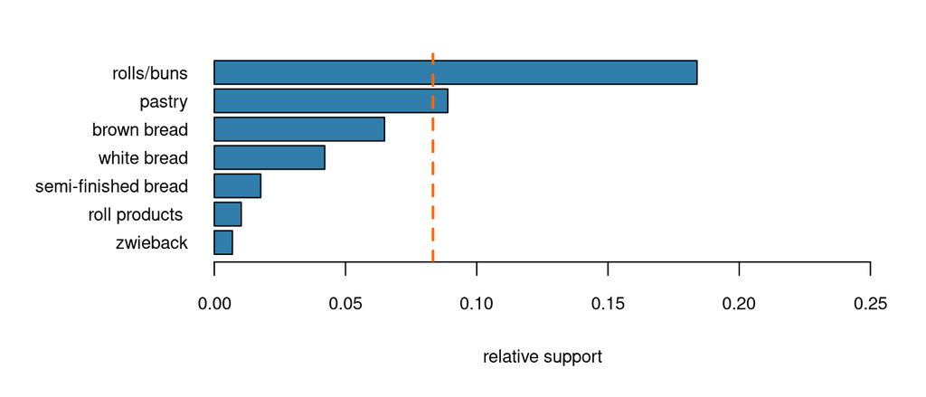

Relative support for products from ‘bread and backed goods’ group

```r
par(mar= c(5.1, 8.1, 2, 2.1))
barplot(rev(gr_prod_2), horiz = TRUE, col = col_1, las = 1, xlim = c(0, 0.25),
       xlab = 'relative support', ylab = '', cex.axis = 0.8, cex.lab = 0.8, cex.names = 0.8)
abline(v = mean(gr_prod_1), col = col_3, lwd = 2, lty = 2)
```

3. grupa ‘napoje niealkoholowe’ ( *non-alc. drinks* ) - produkty:

```r
(items_lvl2_3 <- list_lvl2$`non-alc. drinks`)
```

```
## [1] "bottled water"         "soda"                  "misc. beverages"
## [4] "fruit/vegetable juice" "syrup"
```

Wsparcie produktów

```r
(gr_prod_3 <- sort(tab_freq[items_lvl2_3], decreasing = TRUE))
```

```
##                  soda         bottled water fruit/vegetable juice
##           0.174377224           0.110523640           0.072292832
##       misc. beverages                 syrup
##           0.028368073           0.003253686
```

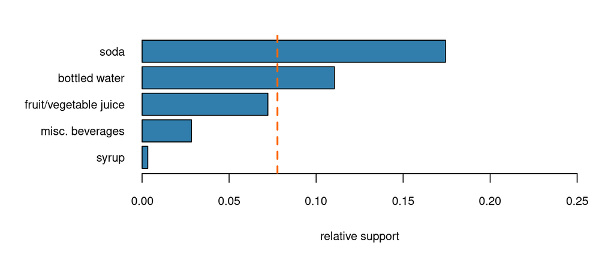

Relative support for products from ‘non-alc. drinks’ group

```r
par(mar= c(5.1, 8.1, 2, 2.1))
barplot(rev(gr_prod_3), horiz = TRUE, col = col_1, las = 1, xlim = c(0, 0.25),
       xlab = 'relative support', ylab = '', cex.axis = 0.8, cex.lab = 0.8, cex.names = 0.8)
abline(v = mean(gr_prod_3), col = col_3, lwd = 2, lty = 2)
```

# 3 EKSPERYMENT - REGUŁY

Przeprowadzono trzy wersje eksperymentu. Każda z nich prowadzona była osobno dla pojedynczych produktów i dla grup produktów ( *level 2* ) - **1. podejście:** support = 0.003, confidence = 0.2,

- **2. podejście:** support = 0.03, confidence = 0.2,
- **3. podejście:** support = 0.003, confidence = 0.5,

## 3.1 Model apriori “produkty” - 1. podejście

Założenia:

- przyjęto *minSup* = 0.003, to oznacza że produkt musi mieć wsparcie bezwzględne powyżej 29 transakcji
- przyjęto *minConf* = 0.2 co oznacza, iż jeżeli w lhs są wskazane produkty to 20% rhs będzie zgodne z regułą

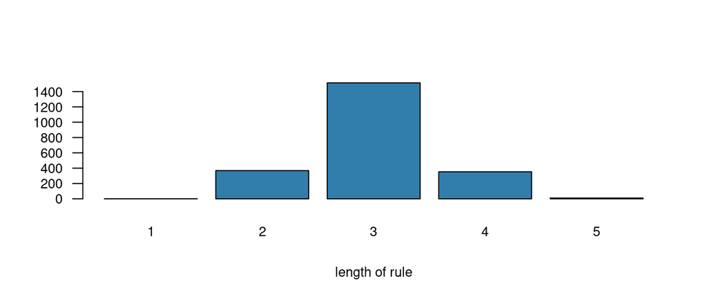

Length of the associate rules = LHS+RHS (products)

```r
barplot(table(size(rules_groc)), col = col_1,  cex.axis = 0.8, cex.names = 0.8, cex.lab = 0.8, las = 1,
        xlab = 'length of rule')
```

```r
summary(rules_groc)
```

```
## set of 2246 rules
##
## rule length distribution (lhs + rhs):sizes
##    1    2    3    4    5
##    1  368 1514  353   10
##
##    Min. 1st Qu.  Median    Mean 3rd Qu.    Max.
##   1.000   3.000   3.000   3.001   3.000   5.000
##
## summary of quality measures:
##     support           confidence        coverage             lift
##  Min.   :0.003050   Min.   :0.2000   Min.   :0.003559   Min.   : 0.8076
##  1st Qu.:0.003559   1st Qu.:0.2587   1st Qu.:0.009278   1st Qu.: 1.7277
##  Median :0.004372   Median :0.3400   Median :0.013727   Median : 2.1491
##  Mean   :0.006284   Mean   :0.3669   Mean   :0.019797   Mean   : 2.2506
##  3rd Qu.:0.006202   3rd Qu.:0.4588   3rd Qu.:0.020946   3rd Qu.: 2.6622
##  Max.   :0.255516   Max.   :0.8857   Max.   :1.000000   Max.   :11.4214
##      count
##  Min.   :  30.0
##  1st Qu.:  35.0
##  Median :  43.0
##  Mean   :  61.8
##  3rd Qu.:  61.0
##  Max.   :2513.0
##
## mining info:
##       data ntransactions support confidence
##  Groceries          9835   0.003        0.2
```

PODSUMOWANIE

Znalezieno 2246 reguł asocjacyjnych dla żądanych parametrow przeszukiwania; większośc reguł - 1514 z 2246 (67,4%) - ma długość (lhs+rhs) równa 3 (3 elementy)

```r
inspect(sort(rules_groc, by = 'lift')[1:10])
```

```
##      lhs                        rhs                      support confidence    coverage      lift count
## [1]  {Instant food products} => {hamburger meat}     0.003050330  0.3797468 0.008032537 11.421438    30
## [2]  {flour}                 => {sugar}              0.004982206  0.2865497 0.017386884  8.463112    49
## [3]  {processed cheese}      => {white bread}        0.004168785  0.2515337 0.016573462  5.975445    41
## [4]  {citrus fruit,
##       tropical fruit,
##       other vegetables,
##       whole milk}            => {root vegetables}    0.003152008  0.6326531 0.004982206  5.804238    31
## [5]  {tropical fruit,
##       root vegetables,
##       other vegetables,
##       whole milk}            => {citrus fruit}       0.003152008  0.4492754 0.007015760  5.428284    31
## [6]  {liquor}                => {bottled beer}       0.004677173  0.4220183 0.011082867  5.240594    46
## [7]  {citrus fruit,
##       root vegetables,
##       other vegetables,
##       whole milk}            => {tropical fruit}     0.003152008  0.5438596 0.005795628  5.183004    31
## [8]  {berries,
##       whole milk}            => {whipped/sour cream} 0.004270463  0.3620690 0.011794611  5.050990    42
## [9]  {herbs,
##       whole milk}            => {root vegetables}    0.004168785  0.5394737 0.007727504  4.949369    41
## [10] {tropical fruit,
##       whole milk,
##       yogurt}                => {curd}               0.003965430  0.2617450 0.015149975  4.912713    39
```

```r
inspect(sort(rules_groc, by = 'confidence')[1:10])
```

```
##      lhs                     rhs                    support confidence    coverage     lift count
## [1]  {citrus fruit,
##       tropical fruit,
##       root vegetables,
##       whole milk}         => {other vegetables} 0.003152008  0.8857143 0.003558719 4.577509    31
## [2]  {root vegetables,
##       butter,
##       yogurt}             => {whole milk}       0.003050330  0.7894737 0.003863752 3.089723    30
## [3]  {citrus fruit,
##       tropical fruit,
##       root vegetables}    => {other vegetables} 0.004473818  0.7857143 0.005693950 4.060694    44
## [4]  {root vegetables,
##       other vegetables,
##       brown bread}        => {whole milk}       0.003152008  0.7750000 0.004067107 3.033078    31
## [5]  {onions,
##       butter}             => {whole milk}       0.003050330  0.7500000 0.004067107 2.935237    30
## [6]  {tropical fruit,
##       curd,
##       yogurt}             => {whole milk}       0.003965430  0.7500000 0.005287239 2.935237    39
## [7]  {curd,
##       domestic eggs}      => {whole milk}       0.004778851  0.7343750 0.006507372 2.874086    47
## [8]  {tropical fruit,
##       butter,
##       yogurt}             => {whole milk}       0.003355363  0.7333333 0.004575496 2.870009    33
## [9]  {tropical fruit,
##       root vegetables,
##       whipped/sour cream} => {other vegetables} 0.003355363  0.7333333 0.004575496 3.789981    33
## [10] {butter,
##       curd}               => {whole milk}       0.004880529  0.7164179 0.006812405 2.803808    48
```

Reguły o wartości pewności = x oznaczają, że za każdym razem, gdy zakupiono produkty z LHS, produkty z RHS  
były kupowane w x przypadków. (conf(X->Y) można intepretować jak prawdopodobieństwo warunkowe P(Y|X)) tzn.

- gdy zakupiono owoce cytrusowe, owoce tropikalne, warzywa korzeniowe, mleko pełne to w 88% przypadków zakupiono inne warzywa, równiez inne warzywa (reguła [1]);
- gdy zakupiono warzywa korzeniowe, masło i jogurt to w 79% przypadkach zakupiono również mleko pełne (regula [2]);
- gdy zakupiono owoce cytrusowe, owoce tropikalne, warzywa korzeniowe to w 79% przypadków zakupiono również inne warzywa (regula [3]),

```r
inspect(sort(rules_groc, by = 'support')[1:10])
```

```
##      lhs                   rhs                support    confidence coverage
## [1]  {}                 => {whole milk}       0.25551601 0.2555160  1.0000000
## [2]  {other vegetables} => {whole milk}       0.07483477 0.3867578  0.1934926
## [3]  {whole milk}       => {other vegetables} 0.07483477 0.2928770  0.2555160
## [4]  {rolls/buns}       => {whole milk}       0.05663447 0.3079049  0.1839349
## [5]  {whole milk}       => {rolls/buns}       0.05663447 0.2216474  0.2555160
## [6]  {yogurt}           => {whole milk}       0.05602440 0.4016035  0.1395018
## [7]  {whole milk}       => {yogurt}           0.05602440 0.2192598  0.2555160
## [8]  {root vegetables}  => {whole milk}       0.04890696 0.4486940  0.1089985
## [9]  {root vegetables}  => {other vegetables} 0.04738180 0.4347015  0.1089985
## [10] {other vegetables} => {root vegetables}  0.04738180 0.2448765  0.1934926
##      lift     count
## [1]  1.000000 2513
## [2]  1.513634  736
## [3]  1.513634  736
## [4]  1.205032  557
## [5]  1.205032  557
## [6]  1.571735  551
## [7]  1.571735  551
## [8]  1.756031  481
## [9]  2.246605  466
## [10] 2.246605  466
```

Parametry określające ‘jakość’ otrzymanych reguł (przegląd)

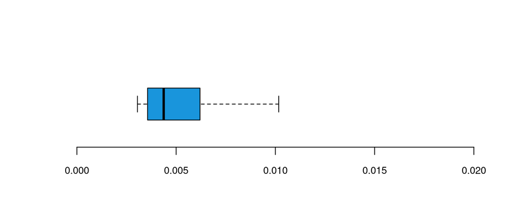

Boxplot of quality measures - support

```r
boxplot(quality(rules_groc)[1], horizontal = TRUE, col = col_0,
        cex.axis = 0.8, cex.lab = 0.8, las = 1, outline = FALSE, frame = FALSE, ylim = c(0, 0.02))
```

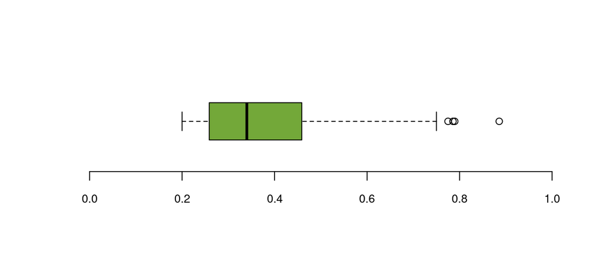

Boxplot of quality measures - confidence

```r
boxplot(quality(rules_groc)[2], horizontal = TRUE, col = col_2,
        cex.axis = 0.8, cex.lab = 0.8, las = 1, frame = FALSE, ylim = c(0, 1))
```

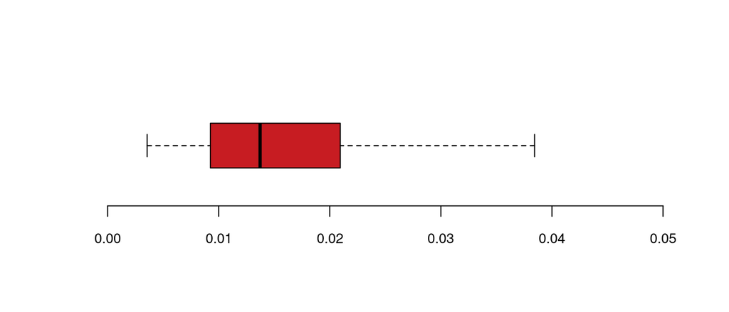

```r
boxplot(quality(rules_groc)[3], horizontal = TRUE, col = col_4,
        cex.axis = 0.8, cex.lab = 0.8, las = 1, outline = FALSE, frame = FALSE, ylim = c(0, 0.05))
```

**Wnioski dot. wartości miar jakości reguł**

Analiza długości reguł

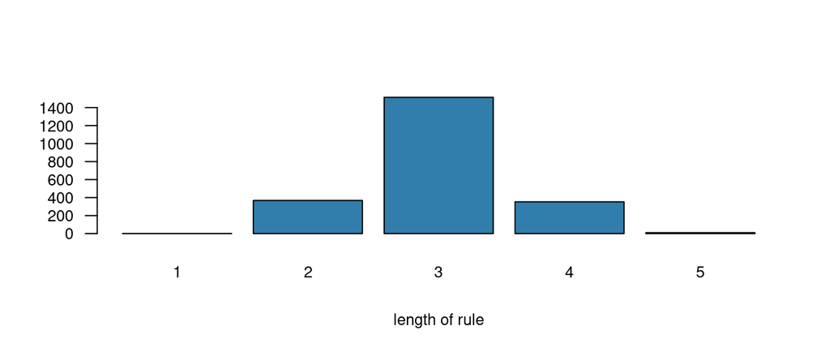

Length of the associate rules = LHS+RHS

```r
barplot(table(size(rules_groc)), col = col_1, cex.axis = 0.8, cex.names = 0.8, cex.lab = 0.8, las = 1,
        xlab = 'length of rule')
```

**Wnioski dot. długości reguł**

67,4% (1514/2246) reguł ma długość (LHS+RHS) wynoszącą 3 (reguła składa się z trzech elementów = produktów), natomiast 17% i 15,7% ma długość odpowiednio - 2 i 4; występuje jedna reguła, gdzie LHS to zbiór pusty.

Analiza długości LHS i RHS

```r
summary(size(rules_groc@rhs))
```

```
##    Min. 1st Qu.  Median    Mean 3rd Qu.    Max.
##       1       1       1       1       1       1
```

```r
summary(size(rules_groc@lhs))
```

```
##    Min. 1st Qu.  Median    Mean 3rd Qu.    Max.
##   0.000   2.000   2.000   2.001   2.000   4.000
```

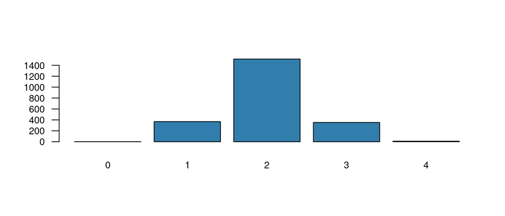

Length of the associate rules - LHS

```r
barplot(table(size(rules_groc@lhs)), col = col_1,  cex.axis = 0.8, cex.names = 0.8, las = 1)
```

## 3.2 Model apriori “grupy produktów” - 1. podejście

Założenia:

- przyjęto *minSup* = 0.003, to oznacza, że grupa produktów musi mieć wsparcie bezwzględne powyżej 29 transakcji
- przyjęto *minConf* = 0.2 co oznacza, iż jeżeli w lhs są wskazane grupy produktóœ to 20% rhs będzie zgodne z regułą

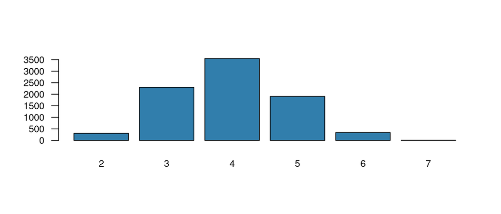

Length of the associate rules = LHS+RHS (products group)

```r
barplot(table(size(rules_groc_lvl2)), col = col_1, cex.axis = 0.8, cex.names = 0.8, las = 1)
```

```r
summary(rules_groc_lvl2)
```

```
## set of 8411 rules
##
## rule length distribution (lhs + rhs):sizes
##    2    3    4    5    6    7
##  306 2303 3548 1905  342    7
##
##    Min. 1st Qu.  Median    Mean 3rd Qu.    Max.
##   2.000   3.000   4.000   3.964   5.000   7.000
##
## summary of quality measures:
##     support           confidence        coverage             lift
##  Min.   :0.003050   Min.   :0.2000   Min.   :0.003152   Min.   :0.6371
##  1st Qu.:0.003559   1st Qu.:0.3690   1st Qu.:0.006812   1st Qu.:1.6619
##  Median :0.004575   Median :0.5079   Median :0.010269   Median :1.9328
##  Mean   :0.007222   Mean   :0.5098   Mean   :0.016533   Mean   :2.0486
##  3rd Qu.:0.007016   3rd Qu.:0.6327   3rd Qu.:0.016879   3rd Qu.:2.3271
##  Max.   :0.187697   Max.   :1.0000   Max.   :0.443010   Max.   :9.1590
##      count
##  Min.   :  30.00
##  1st Qu.:  35.00
##  Median :  45.00
##  Mean   :  71.03
##  3rd Qu.:  69.00
##  Max.   :1846.00
##
## mining info:
##            data ntransactions support confidence
##  Groceries_lvl2          9835   0.003        0.2
```

PODSUMOWANIE

Znalezieno 8411 reguł asocjacyjnych dla żądanych parametrów przeszukiwania, tj. support = 0.003, confidence = 0.2 oraz minlen=2 42% reguł - 3548 z 8411 - ma długość (lhs+rhs) równą 4 (4 elementy), a 27% i 22% reguł - ma długość - odpowiednio 3 i 5 elementów.

```r
inspect(sort(rules_groc_lvl2, by = 'lift')[1:10])
```

```
##      lhs                  rhs                support confidence    coverage     lift count
## [1]  {dairy produce,
##       sweetener,
##       vinegar/oils}    => {staple foods} 0.003253686  0.4637681 0.007015760 9.158955    32
## [2]  {sweetener,
##       vinegar/oils}    => {staple foods} 0.003660397  0.4186047 0.008744281 8.267022    36
## [3]  {dairy produce,
##       staple foods,
##       vinegar/oils}    => {sweetener}    0.003253686  0.3076923 0.010574479 8.026933    32
## [4]  {staple foods,
##       vinegar/oils}    => {sweetener}    0.003660397  0.2880000 0.012709710 7.513210    36
## [5]  {dairy produce,
##       fruit,
##       sweetener}       => {staple foods} 0.003965430  0.3451327 0.011489578 6.816025    39
## [6]  {dairy produce,
##       non-alc. drinks,
##       sweetener}       => {staple foods} 0.003558719  0.3181818 0.011184545 6.283771    35
## [7]  {dairy produce,
##       sweetener,
##       vegetables}      => {staple foods} 0.003965430  0.3145161 0.012608033 6.211378    39
## [8]  {dairy produce,
##       fruit,
##       staple foods}    => {sweetener}    0.003965430  0.2363636 0.016776817 6.166144    39
## [9]  {dairy produce,
##       sweetener}       => {staple foods} 0.007727504  0.3003953 0.025724453 5.932505    76
## [10] {fruit,
##       sweetener}       => {staple foods} 0.004270463  0.2957746 0.014438231 5.841252    42
```

Reguły o wartości lift = x oznacza, że elementy z LHS i RHS występują ze sobą x razy częściej w porównaniu do zakupów gdzie zakłada się, że nie mają ze sobą zwiazku; tzn. * produkty z grup: produkty mleczne, słodycze,ocet/olej wraz z podstawowymi produktami (mąka, ryz, kasze) są 9,2 raza częściej kupowane razem niż osobno (dotyczy LHS i RHS) (reguła [1]),

- słodycze oraz ocet/olej są kupowane razem z podstawowymi produktami (mąka, ryz, kasze) 8,3 raza częściej niż osobno (reguła [2])
- reguła [3] jest bardzo podobna do [1] - ale lift = 8,0
- reguła [4] jest bardzo podobno do [2] - ale lift = 7,5

```r
inspect(sort(rules_groc_lvl2, by = 'confidence')[1:10])
```

```
##      lhs                         rhs                 support confidence    coverage     lift count
## [1]  {chocolate,
##       fruit,
##       staple foods}           => {dairy produce} 0.003558719  1.0000000 0.003558719 2.257287    35
## [2]  {eggs,
##       fruit,
##       staple foods}           => {dairy produce} 0.003660397  0.9729730 0.003762074 2.196279    36
## [3]  {cheese,
##       eggs,
##       perfumery}              => {dairy produce} 0.003660397  0.9729730 0.003762074 2.196279    36
## [4]  {eggs,
##       fruit,
##       non-alc. drinks,
##       vinegar/oils}           => {dairy produce} 0.003457041  0.9714286 0.003558719 2.192793    34
## [5]  {frozen foods,
##       fruit,
##       non-alc. drinks,
##       staple foods}           => {dairy produce} 0.003152008  0.9687500 0.003253686 2.186747    31
## [6]  {frozen foods,
##       fruit,
##       non-alc. drinks,
##       vinegar/oils}           => {dairy produce} 0.003050330  0.9677419 0.003152008 2.184471    30
## [7]  {bread and backed goods,
##       cheese,
##       fruit,
##       non-alc. drinks,
##       perfumery}              => {dairy produce} 0.003050330  0.9677419 0.003152008 2.184471    30
## [8]  {bread and backed goods,
##       fruit,
##       pork,
##       sausage}                => {dairy produce} 0.004880529  0.9600000 0.005083884 2.166996    48
## [9]  {bread and backed goods,
##       cheese,
##       non-alc. drinks,
##       perfumery}              => {dairy produce} 0.004270463  0.9545455 0.004473818 2.154683    42
## [10] {bread and backed goods,
##       eggs,
##       fruit,
##       vinegar/oils}           => {dairy produce} 0.003863752  0.9500000 0.004067107 2.144423    38
```

Reguły o wartości pewności = x oznacza, że za każdym razem, gdy zakupiono produkty z LHS, produkty z RHS były kupowane x przypadków (conf(X->Y) można intepretować jak prawdopodobieństwo warunkowe P(Y|X)) tzn. jeżeli zakupiono produkty z grup czekolada, owoce, podstawowe produkty (mąka, ryz, kasze) to na 100% zakupiono produkt z działu produkty mleczne (reguła [1].)

**UWAGA** ponieważ produkty mleczne występują w 44% transakcji - tworzą reguły o dużej pewności, gdy są w następniku wynika to z definicji conf(X->Y) = sup(X->Y) / sup(X) (produkty mleczne ‘budują’ wartość sup(X->Y))

Sprawdzenie jak wyglądaja reguły, gdy poprzednikiem są produkty mleczne

```r
inspect(sort(subset(rules_groc_lvl2, subset = lhs %in% 'dairy produce' & confidence > 0.80), by = 'confidence'))
```

```
##      lhs                            rhs                          support confidence    coverage     lift count
## [1]  {dairy produce,
##       frozen foods,
##       fruit,
##       poultry}                   => {vegetables}             0.004168785  0.8367347 0.004982206 3.064911    41
## [2]  {chocolate,
##       dairy produce,
##       non-alc. drinks,
##       sausage,
##       vegetables}                => {bread and backed goods} 0.003558719  0.8333333 0.004270463 2.411958    35
## [3]  {cheese,
##       dairy produce,
##       fruit,
##       staple foods}              => {vegetables}             0.003863752  0.8260870 0.004677173 3.025909    38
## [4]  {dairy produce,
##       non-alc. drinks,
##       poultry,
##       sausage}                   => {bread and backed goods} 0.004067107  0.8163265 0.004982206 2.362734    40
## [5]  {dairy produce,
##       poultry,
##       staple foods}              => {vegetables}             0.003965430  0.8125000 0.004880529 2.976141    39
## [6]  {chocolate,
##       dairy produce,
##       fruit,
##       non-alc. drinks,
##       sausage}                   => {bread and backed goods} 0.004372140  0.8113208 0.005388917 2.348246    43
## [7]  {beef,
##       dairy produce,
##       fruit,
##       pork}                      => {vegetables}             0.003457041  0.8095238 0.004270463 2.965239    34
## [8]  {dairy produce,
##       fruit,
##       non-alc. drinks,
##       sausage,
##       vinegar/oils}              => {bread and backed goods} 0.003863752  0.8085106 0.004778851 2.340112    38
## [9]  {chocolate,
##       dairy produce,
##       long-life bakery products,
##       sausage}                   => {bread and backed goods} 0.004270463  0.8076923 0.005287239 2.337744    42
## [10] {chocolate,
##       dairy produce,
##       non-alc. drinks,
##       sausage}                   => {bread and backed goods} 0.007015760  0.8023256 0.008744281 2.322211    69
```

Należy zauważyć, iż reguły zawierające w poprzedniku ‘produkty mleczne’ mają równiez stosunkowo duża pewność, a następnikiem są grupy produktów z największym wsparciem, tj. ‘pieczywo i wypieki’ oraz ‘warzywa’ (bardzo duże sup(X->Y)) - z 258 reguł pokazane są 3 przykałdowe:

```r
inspect(sort(subset(rules_groc_lvl2, subset = lhs %in% 'bread and backed goods' & confidence > 0.80), by = 'confidence')[c(1, 129, 258)])
```

```
##     lhs                         rhs                 support confidence    coverage     lift count
## [1] {bread and backed goods,
##      cheese,
##      fruit,
##      non-alc. drinks,
##      perfumery}              => {dairy produce} 0.003050330  0.9677419 0.003152008 2.184471    30
## [2] {bread and backed goods,
##      cheese,
##      frozen foods,
##      sausage,
##      vegetables}             => {dairy produce} 0.003457041  0.8500000 0.004067107 1.918694    34
## [3] {bread and backed goods,
##      perfumery,
##      vegetables}             => {dairy produce} 0.013523132  0.8012048 0.016878495 1.808549   133
```

**CIEKAWOSTKA** jeżeli w poprzedniku występuje produkt z grupy ‘pieczywo i wypieki’ to z pewnością **> 0,80** w następniku wystąpi produkt z działu ‘produkty mleczne’ (takich reguł jest 258); z powyższego zestawieni wynika, iż jeżeli w poprzedniku wystąpiła grupa ‘produkty mleczne’ to z pewnością **> 0,80** wystąpia podukty z grupy ‘pieczywo i wypieki’ lub ‘warzywa’.

```r
inspect(sort(rules_groc_lvl2, by = 'support')[1:10])
```

```
##      lhs                         rhs                      support   confidence
## [1]  {bread and backed goods} => {dairy produce}          0.1876970 0.5432607
## [2]  {dairy produce}          => {bread and backed goods} 0.1876970 0.4236860
## [3]  {vegetables}             => {dairy produce}          0.1704118 0.6242086
## [4]  {dairy produce}          => {vegetables}             0.1704118 0.3846683
## [5]  {fruit}                  => {dairy produce}          0.1563803 0.6277551
## [6]  {dairy produce}          => {fruit}                  0.1563803 0.3529952
## [7]  {non-alc. drinks}        => {dairy produce}          0.1519065 0.4777742
## [8]  {dairy produce}          => {non-alc. drinks}        0.1519065 0.3428965
## [9]  {non-alc. drinks}        => {bread and backed goods} 0.1242501 0.3907899
## [10] {bread and backed goods} => {non-alc. drinks}        0.1242501 0.3596233
##      coverage  lift     count
## [1]  0.3455008 1.226295 1846
## [2]  0.4430097 1.226295 1846
## [3]  0.2730046 1.409018 1676
## [4]  0.4430097 1.409018 1676
## [5]  0.2491103 1.417024 1538
## [6]  0.4430097 1.417024 1538
## [7]  0.3179461 1.078474 1494
## [8]  0.4430097 1.078474 1494
## [9]  0.3179461 1.131083 1222
## [10] 0.3455008 1.131083 1222
```

Reguła o wartości wsparcia względnego = x oznacza, że x transakcji zawiera wymienione w LHS i RHS produkty.

- reguła o wsparciu względnym 0,18 oznacza, iż w 18% transakcji występują produkty z działu produkty mleczne oraz pieczywo i wypieki (tu co jest następnikiem a co poprzednikiem nie ma znaczenia) (reguła [1], [2]),
- reguła o wsparciu względnym 0,17 oznacza, iż w 17% transakcji występują produkty z działu warzywa oraz produkty mleczne (tu co jest następnikiem a co poprzednikiem nie ma znaczenia) (reguła [3], [4]),
- reguła o wsparciu względnym 0,156 oznacza, iż w 15,6% transakcji występują produkty z działu owoce oraz produkty mleczne (tu co jest następnikiem a co poprzednikiem nie ma znaczenia) (reguła [5], [6]),
- reguła o wsparciu względnym 0,152 oznacza, iż w 15,2% transakcji występują produkty z napoje niealkoholowe oraz produkty mleczne (tu co jest następnikiem a co poprzednikiem nie ma znaczenia) (reguła [7], [8]),
- reguła o wsparciu względnym 0,124 oznacza, iż w 12,4% transakcji występują produkty z napoje niealkoholowe oraz pieczywo i wypieki (tu co jest następnikiem a co poprzednikiem nie ma znaczenia) (reguła [9], [10]).

Powyższe reguły sa zbudowane z grup produktów o największym wsparciu (częste produkty dają częste reguły), ale aby znaleźć odpowiedź na pytanie, które działy sklepu należy rozwijać, należy przeanalizować jeszcze zaufanie ww. reguł. tzn. zakup których grup produktów warunkuje zakup innych grup.

Parametry określające ‘jakość’ otrzymanych reguł (przegląd)

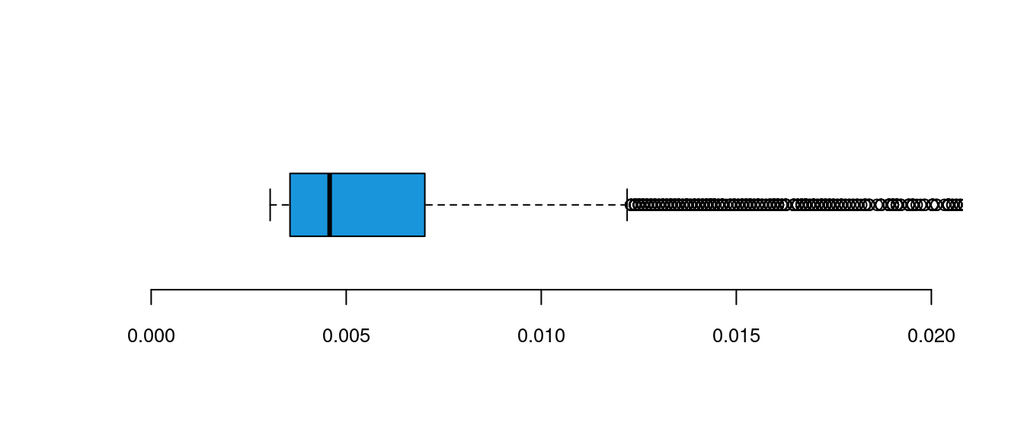

Boxplot of quality measures - support

```r
boxplot(quality(rules_groc_lvl2)[1], horizontal = TRUE, col = col_0,
        cex.axis = 0.8, cex.lab = 0.8, las = 1,  frame = FALSE, ylim = c(0, 0.02))
```

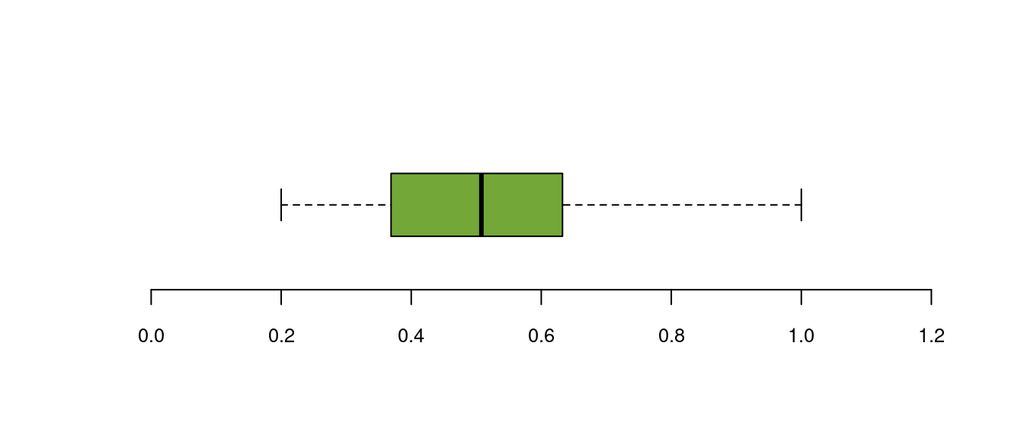

Boxplot of quality measures - confidence

```r
boxplot(quality(rules_groc_lvl2)[2], horizontal = TRUE, col = col_2,
        cex.axis = 0.8, cex.lab = 0.8, las = 1, frame = FALSE, ylim = c(0, 1.2))
```

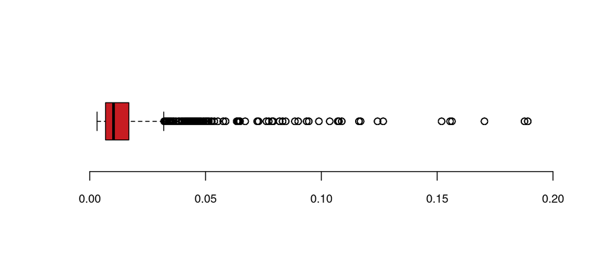

```r
boxplot(quality(rules_groc_lvl2)[3], horizontal = TRUE, col = col_4,
        cex.axis = 0.8, cex.lab = 0.8, las = 1, frame = FALSE, ylim = c(0, 0.2))
```

## 3.3 Model apriori “produkty” - 2. podejście

Założenia:

- przyjęto *minSup* = 0.03, to oznacza że produkt musi mieć wsparcie bezwzględne powyżej 295 transakcji
- przyjęto *minConf* = 0.2 co oznacza, iż jeżeli w lhs są wskazane produkty to 20% rhs będzie zgodne z regułą

[figure not shown]

Length of the associate rules = LHS+RHS (products)

```r
barplot(table(size(rules_groc)), col = col_1, cex.axis = 0.8, cex.names = 0.8, cex.lab = 0.8, las = 1,
        xlab = 'lenght of rule')
```

```r
summary(rules_groc_new)
```

```
## set of 25 rules
##
## rule length distribution (lhs + rhs):sizes
##  2
## 25
##
##    Min. 1st Qu.  Median    Mean 3rd Qu.    Max.
##       2       2       2       2       2       2
##
## summary of quality measures:
##     support          confidence        coverage            lift
##  Min.   :0.03010   Min.   :0.2084   Min.   :0.07168   Min.   :0.8991
##  1st Qu.:0.03437   1st Qu.:0.2297   1st Qu.:0.10493   1st Qu.:1.2050
##  Median :0.04260   Median :0.3109   Median :0.13950   Median :1.5136
##  Mean   :0.04444   Mean   :0.3129   Mean   :0.15244   Mean   :1.5050
##  3rd Qu.:0.04891   3rd Qu.:0.3868   3rd Qu.:0.19349   3rd Qu.:1.6085
##  Max.   :0.07483   Max.   :0.4496   Max.   :0.25552   Max.   :2.2466
##      count
##  Min.   :296.0
##  1st Qu.:338.0
##  Median :419.0
##  Mean   :437.1
##  3rd Qu.:481.0
##  Max.   :736.0
##
## mining info:
##       data ntransactions support confidence
##  Groceries          9835    0.03        0.2
```

PODSUMOWANIE

Znalezieno 25 reguł asocjacyjnych dla żądanych parametrów przeszukiwania; wszytkie reguły mają długośc 2 (2 elementy w lhs+rhs).

```r
inspect(sort(rules_groc_new, by = 'lift')[1:10])
```

```
##      lhs                     rhs                support    confidence
## [1]  {root vegetables}    => {other vegetables} 0.04738180 0.4347015
## [2]  {other vegetables}   => {root vegetables}  0.04738180 0.2448765
## [3]  {sausage}            => {rolls/buns}       0.03060498 0.3257576
## [4]  {tropical fruit}     => {other vegetables} 0.03589222 0.3420543
## [5]  {whipped/sour cream} => {whole milk}       0.03223183 0.4496454
## [6]  {root vegetables}    => {whole milk}       0.04890696 0.4486940
## [7]  {yogurt}             => {other vegetables} 0.04341637 0.3112245
## [8]  {other vegetables}   => {yogurt}           0.04341637 0.2243826
## [9]  {tropical fruit}     => {whole milk}       0.04229792 0.4031008
## [10] {yogurt}             => {whole milk}       0.05602440 0.4016035
##      coverage   lift     count
## [1]  0.10899847 2.246605 466
## [2]  0.19349263 2.246605 466
## [3]  0.09395018 1.771048 301
## [4]  0.10493137 1.767790 353
## [5]  0.07168277 1.759754 317
## [6]  0.10899847 1.756031 481
## [7]  0.13950178 1.608457 427
## [8]  0.19349263 1.608457 427
## [9]  0.10493137 1.577595 416
## [10] 0.13950178 1.571735 551
```

Reguły o wartości lift = x oznacza, że elementy z LHS i RHS występują ze sobą x razy częściej w porównaniu do zakupów gdzie zakłada się, że nie mają ze sobą zwiazku; tzn.

- warzywa korzeniowe oraz inne warzywa są kupowane 2,2 razy częściej razem niż osobno, (reguła ta niezależnie od kolejności ma takie samo wsparcie i lift, ale zależenie od kolejności - inne zaufanie różniące się dwukrotnie) (reguła [1], [2])
- kiełbasa oraz bułki i bułeczki kupowane są 1,77 razy częściej razem niż osobno (reguła [3]),
- owoce tropikalne i inne warzywa kupowane są 1,77 razy częściej razem niż osobno (reguła [4]).

Zwraca uwagę fakt, iż w zasadzie reguły te są zbudowane tylko z produktów częstych (z wyjątekim [3] gdzie lhs = {sausage}) W porównaniu reguł w 1. podejściu - zwraca uwagę spadek wartości lift dla reguł (poprzedniu było powyżej 4,9 - do 11 - teraz jest max 2,2)

```r
inspect(sort(rules_groc_new, by = 'confidence')[1:10])
```

```
##      lhs                     rhs                support    confidence
## [1]  {whipped/sour cream} => {whole milk}       0.03223183 0.4496454
## [2]  {root vegetables}    => {whole milk}       0.04890696 0.4486940
## [3]  {root vegetables}    => {other vegetables} 0.04738180 0.4347015
## [4]  {tropical fruit}     => {whole milk}       0.04229792 0.4031008
## [5]  {yogurt}             => {whole milk}       0.05602440 0.4016035
## [6]  {pip fruit}          => {whole milk}       0.03009659 0.3978495
## [7]  {other vegetables}   => {whole milk}       0.07483477 0.3867578
## [8]  {pastry}             => {whole milk}       0.03324860 0.3737143
## [9]  {citrus fruit}       => {whole milk}       0.03050330 0.3685504
## [10] {tropical fruit}     => {other vegetables} 0.03589222 0.3420543
##      coverage   lift     count
## [1]  0.07168277 1.759754 317
## [2]  0.10899847 1.756031 481
## [3]  0.10899847 2.246605 466
## [4]  0.10493137 1.577595 416
## [5]  0.13950178 1.571735 551
## [6]  0.07564820 1.557043 296
## [7]  0.19349263 1.513634 736
## [8]  0.08896797 1.462587 327
## [9]  0.08276563 1.442377 300
## [10] 0.10493137 1.767790 353
```

Reguły o wartości pewności = x oznacza, że za każdym razem, gdy zakupiono produkty z LHS, produkty z RHS były również kupowane x przypadków (conf(X->Y) można intepretować jak prawdopodobieństwo warunkowe P(Y|X)) tzn.

- gdy zakupiono bitą śmietanę i śmietanę zwykłą to w 45% przypadków zakupiono też mleko pełne (reguła [1]),
- gdy zakupiono warzywa korzeniowe to w 44,9% przypadkach zakupiono również mleko pełne (reguła [2]),
- gdy zakupiono warzywa korzeniowe to w 43,4% przypadkach zakupiono również inne warzywa (reguła [3]).

W porównaniu reguł w 1. podejściu - zwraca uwagę spadek wartości zaufania reguł (poprzednio było powyżej 70% teraz jest max 45%)

```r
inspect(sort(rules_groc_new, by = 'support')[1:10])
```

```
##      lhs                   rhs                support    confidence coverage
## [1]  {other vegetables} => {whole milk}       0.07483477 0.3867578  0.1934926
## [2]  {whole milk}       => {other vegetables} 0.07483477 0.2928770  0.2555160
## [3]  {rolls/buns}       => {whole milk}       0.05663447 0.3079049  0.1839349
## [4]  {whole milk}       => {rolls/buns}       0.05663447 0.2216474  0.2555160
## [5]  {yogurt}           => {whole milk}       0.05602440 0.4016035  0.1395018
## [6]  {whole milk}       => {yogurt}           0.05602440 0.2192598  0.2555160
## [7]  {root vegetables}  => {whole milk}       0.04890696 0.4486940  0.1089985
## [8]  {root vegetables}  => {other vegetables} 0.04738180 0.4347015  0.1089985
## [9]  {other vegetables} => {root vegetables}  0.04738180 0.2448765  0.1934926
## [10] {yogurt}           => {other vegetables} 0.04341637 0.3112245  0.1395018
##      lift     count
## [1]  1.513634 736
## [2]  1.513634 736
## [3]  1.205032 557
## [4]  1.205032 557
## [5]  1.571735 551
## [6]  1.571735 551
## [7]  1.756031 481
## [8]  2.246605 466
## [9]  2.246605 466
## [10] 1.608457 427
```

Reguła o wartości wsparcia względnego = x oznacza, że x transakcji zawiera wymienione w LHS i RHS produkty.

Reguły powyższe - z wyjątkiem, że tu nie występuje reguła ze zbiorem pustym - są takie same jak otrzymano w 1. podejściu

Sprawdzenie

- dla reguł [1] i [2] - wsparcie 736 transakcje zawierają produkty inne warzywa oraz mleko pełne (wybrano 3 przykładowe)

```r
inspect(subset(subset(Groceries, items %in% 'other vegetables'), items %in% 'whole milk')[c(1, 368, 736)])
```

```
##     items
## [1] {other vegetables,
##      whole milk,
##      condensed milk,
##      long life bakery product}
## [2] {liver loaf,
##      root vegetables,
##      other vegetables,
##      whole milk,
##      frozen vegetables,
##      margarine}
## [3] {frankfurter,
##      tropical fruit,
##      other vegetables,
##      whole milk,
##      frozen meals,
##      rolls/buns,
##      detergent,
##      napkins,
##      newspapers}
```

- dla reguł [3] i [4] - wsparcie 557 transakcje zawierają produkty bułki i bułeczki oraz mleko pełne (wybrano 3 przykładowe)

```r
inspect(subset(subset(Groceries, items %in% 'rolls/buns'), items %in% 'whole milk')[c(1, 278, 557)])
```

```
##     items
## [1] {tropical fruit,
##      pip fruit,
##      berries,
##      whole milk,
##      frozen potato products,
##      rolls/buns,
##      pickled vegetables,
##      chocolate}
## [2] {citrus fruit,
##      tropical fruit,
##      pip fruit,
##      root vegetables,
##      onions,
##      other vegetables,
##      whole milk,
##      yogurt,
##      rolls/buns,
##      brown bread,
##      soda,
##      fruit/vegetable juice}
## [3] {frankfurter,
##      tropical fruit,
##      other vegetables,
##      whole milk,
##      frozen meals,
##      rolls/buns,
##      detergent,
##      napkins,
##      newspapers}
```

**WNIOSKI**

Zwiększczenie wartości minimalnego wsparcia wzglednego ( *minrSup* = 0.03) spowodowało skrócenie reguł - do dwóch elementów: jeden poprzednik i jeden nastepnik, natomiast zasadniczo nie zmieniło zestawienia reguł wg parametru wsparcie bezwzględne; reguły przefitrowane wg parametru lift i zaufanie zawierają najczęstsze produkty - zmiana w stosunku do otrzymanych w 1.podejeściu zestawień wynikająca z wymaganego większego wsparcia poprzedznika reguły (dla zaufania conf = P(XY) / P(X) oraz dla lift = P(XY)/ [P(X) * P(Y)]).

## 3.4 Model apriori “grupy produktów” - 2. podejście

Założenia:

- przyjęto *minSup* = 0.03, to oznacza, że grupa produktów musi mieć wsparcie bezwzględne powyżej 295 transakcji
- przyjęto *minConf* = 0.2 co oznacza, iż jeżeli w lhs są wskazane grupy produktów, to 20% rhs będzie zgodne z regułą

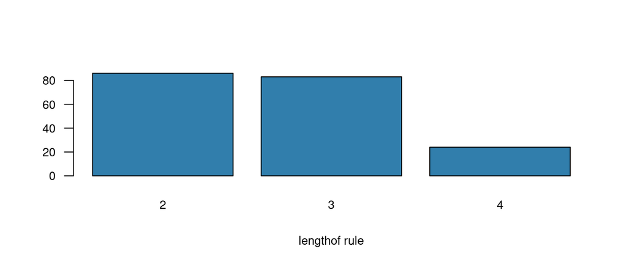

Length of the associate rules = LHS+RHS (products group)

```r
barplot(table(size(rules_groc_lvl2_new)), col = col_1, cex.axis = 0.8, cex.names = 0.8, cex.lab = 0.8, las = 1,
        xlab = 'lengthof rule')
```

```r
summary(rules_groc_lvl2_new)
```

```
## set of 193 rules
##
## rule length distribution (lhs + rhs):sizes
##  2  3  4
## 86 83 24
##
##    Min. 1st Qu.  Median    Mean 3rd Qu.    Max.
##   2.000   2.000   3.000   2.679   3.000   4.000
##
## summary of quality measures:
##     support          confidence        coverage            lift
##  Min.   :0.03010   Min.   :0.2017   Min.   :0.03833   Min.   :0.6669
##  1st Qu.:0.03437   1st Qu.:0.3771   1st Qu.:0.07626   1st Qu.:1.2986
##  Median :0.04423   Median :0.4409   Median :0.10361   Median :1.5224
##  Mean   :0.05543   Mean   :0.4682   Mean   :0.13159   Mean   :1.5183
##  3rd Qu.:0.06396   3rd Qu.:0.5478   3rd Qu.:0.15638   3rd Qu.:1.7101
##  Max.   :0.18770   Max.   :0.7984   Max.   :0.44301   Max.   :2.2873
##      count
##  Min.   : 296.0
##  1st Qu.: 338.0
##  Median : 435.0
##  Mean   : 545.2
##  3rd Qu.: 629.0
##  Max.   :1846.0
##
## mining info:
##            data ntransactions support confidence
##  Groceries_lvl2          9835    0.03        0.2
```

PODSUMOWANIE

Znalezieno 193 reguł asocjacyjnych dla żądanych parametrów przeszukiwania, tj. support = 0.03, confidence = 0.2, minnlen=2 44,5% reguł - 86 z 193 - ma długość (lhs+rhs) równą 2 (2 elementy), 43% reguł - 83 z 193 - ma długość (lhs+rhs) równą 3 (3 elementy), a pozostałe reguły maja długość 4 (4 elementy)

```r
inspect(sort(rules_groc_lvl2_new, by = 'lift')[1:10])
```

```
##      lhs                         rhs             support confidence   coverage     lift count
## [1]  {dairy produce,
##       sausage}                => {cheese}     0.03111337  0.2897727 0.10737163 2.287251   306
## [2]  {bread and backed goods,
##       dairy produce,
##       vegetables}             => {sausage}    0.03284189  0.4007444 0.08195221 2.118990   323
## [3]  {bread and backed goods,
##       dairy produce,
##       fruit}                  => {sausage}    0.03060498  0.3960526 0.07727504 2.094182   301
## [4]  {dairy produce,
##       non-alc. drinks,
##       vegetables}             => {fruit}      0.03304525  0.5126183 0.06446365 2.057796   325
## [5]  {beef}                   => {vegetables} 0.04585663  0.5595533 0.08195221 2.049612   451
## [6]  {dairy produce,
##       fruit}                  => {cheese}     0.03965430  0.2535761 0.15638027 2.001541   390
## [7]  {bread and backed goods,
##       dairy produce,
##       vegetables}             => {fruit}      0.04077275  0.4975186 0.08195221 1.997182   401
## [8]  {bread and backed goods,
##       vegetables}             => {sausage}    0.04382308  0.3770779 0.11621759 1.993850   431
## [9]  {dairy produce,
##       vinegar/oils}           => {vegetables} 0.03141840  0.5355286 0.05866802 1.961610   309
## [10] {bread and backed goods,
##       dairy produce,
##       non-alc. drinks}        => {fruit}      0.03528216  0.4880450 0.07229283 1.959152   347
```

Reguły o wartości lift = x ozanczają, że elementy z LHS i RHS występują ze sobą x razy częściej w porównaniu do zakupów gdzie zakałda się, że nie mają ze sobą związku; tzn.

- produkty z grup: produkty mleczne i kiełabsy wraz z serem są 2,3 raza częściej kupowane razem niż osobno (dotyczy LHS i RHS) (reguła [1]),
- pieczywo i wypieki, produkty mleczne i warzywa razem z kiełbasą są 2,1 raza częściej kupowane niż osobno (reguła [2]),
- pieczywo i wypieki, produkty mleczne i owoce razem z kiełbasą są 2,1 raza częściej kupowane niż osobno (reguła [3]).

Wartości lift są przeciętnie niższe niż w 1. podejściu max. 9,1 (outlier) i 2,3 na Q3 vs max. 2,3 w podejściu 2., różnice wartości nie są jednak tak znaczne jak w przypadku pojedynczych produktów.

```r
inspect(sort(rules_groc_lvl2_new, by = 'confidence')[1:10])
```

```
##      lhs                         rhs                support confidence   coverage     lift count
## [1]  {bread and backed goods,
##       fruit,
##       sausage}                => {dairy produce} 0.03060498  0.7984085 0.03833249 1.802237   301
## [2]  {bread and backed goods,
##       fruit,
##       vegetables}             => {dairy produce} 0.04077275  0.7956349 0.05124555 1.795976   401
## [3]  {cheese,
##       fruit}                  => {dairy produce} 0.03965430  0.7707510 0.05144891 1.739806   390
## [4]  {cheese,
##       vegetables}             => {dairy produce} 0.04219624  0.7628676 0.05531266 1.722011   415
## [5]  {fruit,
##       non-alc. drinks,
##       vegetables}             => {dairy produce} 0.03304525  0.7575758 0.04361973 1.710066   325
## [6]  {bread and backed goods,
##       sausage,
##       vegetables}             => {dairy produce} 0.03284189  0.7494200 0.04382308 1.691656   323
## [7]  {vegetables,
##       vinegar/oils}           => {dairy produce} 0.03141840  0.7481840 0.04199288 1.688866   309
## [8]  {bread and backed goods,
##       fruit,
##       non-alc. drinks}        => {dairy produce} 0.03528216  0.7430407 0.04748348 1.677256   347
## [9]  {frozen foods,
##       fruit}                  => {dairy produce} 0.03070666  0.7401961 0.04148449 1.670835   302
## [10] {fruit,
##       vegetables}             => {dairy produce} 0.07869853  0.7350427 0.10706660 1.659203   774
```

Reguły o wartości pewności = x oznacza, że za każdym razem, gdy zakupiono produkty z LHS, produkty z RHS były kupowane x przypadków conf(X->Y) można intepretować jak prawdopodobieństwo warunkowe P(Y|X)), tzn.

- jeżeli zakupiono produkty z grup pieczywo i wypieki, owoce i kiełbasy to w 80% transakcji zakupiono produkty mleczne (reguła [1]),
- jeżeli zakupiono produkty z grup pieczywo i wypieki, owoce i warzywa to w 80% transakcji zakupiono produkty mleczne (reguła [2])
- jeżeli zakupiono produkty z grup sery i owoce to w 77% transakcji zakupiono produkty mleczne (reguły [3]).

Zwraca uwagę fakt, iż reguły powstały z elementów częstych, w porównaniu do reguł z 1. podejścia = następnik jest taki sam (produkty mleczne) natomiast zmieniła się cześć poprzedników (wymagane wyższe wsparcie), ale reguły mają mniejsze zaufanie (było powyżej 95% jest teraz mniej niż 80%)

**UWAGA** ponieważ produkty mleczne występują w 44% transakcji - tworzą reguły o dużej pewności, gdy są w następniku.

```r
inspect(sort(rules_groc_lvl2_new, by = 'support')[1:10])
```

```
##      lhs                         rhs                      support   confidence
## [1]  {bread and backed goods} => {dairy produce}          0.1876970 0.5432607
## [2]  {dairy produce}          => {bread and backed goods} 0.1876970 0.4236860
## [3]  {vegetables}             => {dairy produce}          0.1704118 0.6242086
## [4]  {dairy produce}          => {vegetables}             0.1704118 0.3846683
## [5]  {fruit}                  => {dairy produce}          0.1563803 0.6277551
## [6]  {dairy produce}          => {fruit}                  0.1563803 0.3529952
## [7]  {non-alc. drinks}        => {dairy produce}          0.1519065 0.4777742
## [8]  {dairy produce}          => {non-alc. drinks}        0.1519065 0.3428965
## [9]  {non-alc. drinks}        => {bread and backed goods} 0.1242501 0.3907899
## [10] {bread and backed goods} => {non-alc. drinks}        0.1242501 0.3596233
##      coverage  lift     count
## [1]  0.3455008 1.226295 1846
## [2]  0.4430097 1.226295 1846
## [3]  0.2730046 1.409018 1676
## [4]  0.4430097 1.409018 1676
## [5]  0.2491103 1.417024 1538
## [6]  0.4430097 1.417024 1538
## [7]  0.3179461 1.078474 1494
## [8]  0.4430097 1.078474 1494
## [9]  0.3179461 1.131083 1222
## [10] 0.3455008 1.131083 1222
```

Reguła o wartości wsparcia względnego = x oznacza, że x transakcji zawiera wymienione w LHS i RHS produkty. reguła o wsparciu względnym 0,18 oznacza, iż w 18% transakcji występują produkty z działu produkty mleczne oraz pieczywo i wypieki (tu co jest następnikiem a co poprzednikiem nie ma znaczenia) (reguła [1], [2]). Reguły powyższe - z wyjątkiem, że tu nie występuje reguła ze zbiorem pustym - są takie same jak otrzymano w 1. podejściu

## 3.5 Model apriori “produkty” - 3. podejście

Założenia:

- przyjęto *minSup* = 0.003, to oznacza że produkt musi mieć wsparcie bezwzględne powyżej 29 transakcji
- przyjęto *minConf* = 0.5 co oznacza, iż jeżeli w lhs są wskazane produkty to 50% rhs będzie zgodne z regułą

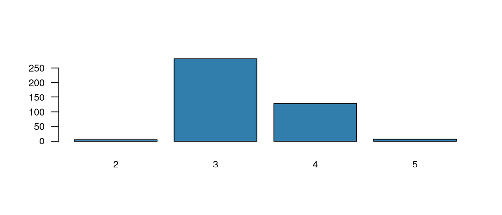

Length of the associate rules = LHS+RHS (products)

```r
barplot(table(size(rules_groc_new_3)), col = col_1, cex.axis = 0.8, cex.names = 0.8, las = 1)
```

```r
summary(rules_groc_new_3)
```

```
## set of 421 rules
##
## rule length distribution (lhs + rhs):sizes
##   2   3   4   5
##   5 281 128   7
##
##    Min. 1st Qu.  Median    Mean 3rd Qu.    Max.
##   2.000   3.000   3.000   3.325   4.000   5.000
##
## summary of quality measures:
##     support           confidence        coverage             lift
##  Min.   :0.003050   Min.   :0.5000   Min.   :0.003559   Min.   :1.957
##  1st Qu.:0.003355   1st Qu.:0.5238   1st Qu.:0.005999   1st Qu.:2.135
##  Median :0.003965   Median :0.5556   Median :0.007016   Median :2.426
##  Mean   :0.004754   Mean   :0.5715   Mean   :0.008477   Mean   :2.522
##  3rd Qu.:0.005186   3rd Qu.:0.6094   3rd Qu.:0.009456   3rd Qu.:2.766
##  Max.   :0.022267   Max.   :0.8857   Max.   :0.043416   Max.   :5.804
##      count
##  Min.   : 30.00
##  1st Qu.: 33.00
##  Median : 39.00
##  Mean   : 46.75
##  3rd Qu.: 51.00
##  Max.   :219.00
##
## mining info:
##       data ntransactions support confidence
##  Groceries          9835   0.003        0.5
```

PODSUMOWANIE

Znalezieno 421 reguł asocjacyjnych dla żądanych parametrów przeszukiwania, tj. support = 0.003, confidence = 0.5; większośc reguł - 281 z 421 (66,7%) - ma długość (lhs+rhs) równa 3 (3 elementy), a spora część reguł - 128 z 421 (30%) - ma długość (lhs+rhs) równa 4 (4 elementy)

```r
inspect(sort(rules_groc_new_3, by = 'lift')[1:10])
```

```
##      lhs                     rhs                    support confidence    coverage     lift count
## [1]  {citrus fruit,
##       tropical fruit,
##       other vegetables,
##       whole milk}         => {root vegetables}  0.003152008  0.6326531 0.004982206 5.804238    31
## [2]  {citrus fruit,
##       root vegetables,
##       other vegetables,
##       whole milk}         => {tropical fruit}   0.003152008  0.5438596 0.005795628 5.183004    31
## [3]  {herbs,
##       whole milk}         => {root vegetables}  0.004168785  0.5394737 0.007727504 4.949369    41
## [4]  {herbs,
##       other vegetables}   => {root vegetables}  0.003863752  0.5000000 0.007727504 4.587220    38
## [5]  {citrus fruit,
##       tropical fruit,
##       root vegetables,
##       whole milk}         => {other vegetables} 0.003152008  0.8857143 0.003558719 4.577509    31
## [6]  {tropical fruit,
##       whole milk,
##       curd}               => {yogurt}           0.003965430  0.6093750 0.006507372 4.368224    39
## [7]  {citrus fruit,
##       tropical fruit,
##       root vegetables}    => {other vegetables} 0.004473818  0.7857143 0.005693950 4.060694    44
## [8]  {tropical fruit,
##       other vegetables,
##       butter}             => {yogurt}           0.003050330  0.5555556 0.005490595 3.982426    30
## [9]  {tropical fruit,
##       whole milk,
##       whipped/sour cream} => {yogurt}           0.004372140  0.5512821 0.007930859 3.951792    43
## [10] {tropical fruit,
##       whole milk,
##       butter}             => {yogurt}           0.003355363  0.5409836 0.006202339 3.877969    33
```

Reguły o wartości lift = x ozancza, że elementy z LHS i RHS występują ze sobą x razy częściej w porównaniu do zakupów gdzie zakałda się, że nie mają ze sobą związku; tzn.

- cytrusy, owoce tropikalne, inne warzywa i pełne mleko oraz warzywa korzeniowe są kupowane 5,8 razy częsciej razem niż osobno (reguła [1]),
- cytrusy, warzywa korzeniowe, inne warzywa i pełne mleko oraz woce tropikalne są kupowane 5,2 razy częsciej razem niż osobno (reguła [2),
- zioła i mleko pełne oraz warzywa korzeniowe są kupowane 4,9 razy częsciej razem niż osobno (reguła [3]).

Zwraca uwagę fakt, iż w zasadzie reguły te są zbudowane głównie z produktów częstych, ale pojawiają się też produkty o znacznie niższym wsparciu (ale z częstych grup produktów).

```r
inspect(sort(rules_groc_new_3, by = 'confidence')[1:10])
```

```
##      lhs                     rhs                    support confidence    coverage     lift count
## [1]  {citrus fruit,
##       tropical fruit,
##       root vegetables,
##       whole milk}         => {other vegetables} 0.003152008  0.8857143 0.003558719 4.577509    31
## [2]  {root vegetables,
##       butter,
##       yogurt}             => {whole milk}       0.003050330  0.7894737 0.003863752 3.089723    30
## [3]  {citrus fruit,
##       tropical fruit,
##       root vegetables}    => {other vegetables} 0.004473818  0.7857143 0.005693950 4.060694    44
## [4]  {root vegetables,
##       other vegetables,
##       brown bread}        => {whole milk}       0.003152008  0.7750000 0.004067107 3.033078    31
## [5]  {onions,
##       butter}             => {whole milk}       0.003050330  0.7500000 0.004067107 2.935237    30
## [6]  {tropical fruit,
##       curd,
##       yogurt}             => {whole milk}       0.003965430  0.7500000 0.005287239 2.935237    39
## [7]  {curd,
##       domestic eggs}      => {whole milk}       0.004778851  0.7343750 0.006507372 2.874086    47
## [8]  {tropical fruit,
##       butter,
##       yogurt}             => {whole milk}       0.003355363  0.7333333 0.004575496 2.870009    33
## [9]  {tropical fruit,
##       root vegetables,
##       whipped/sour cream} => {other vegetables} 0.003355363  0.7333333 0.004575496 3.789981    33
## [10] {butter,
##       curd}               => {whole milk}       0.004880529  0.7164179 0.006812405 2.803808    48
```

Reguły o wartości pewności = x oznacza, że za każdym razem, gdy zakupiono produkty z LHS, produkty z RHS były również kupowane x przypadków (conf(X->Y) można intepretować jak prawdopodobieństwo warunkowe P(Y|X)) tzn.

W porównaniu reguł w 1. podejściu - otrzymaliśmy te same reguły .

```r
inspect(sort(rules_groc_new_3, by = 'support')[1:10])
```

```
##      lhs                                      rhs                support
## [1]  {other vegetables,yogurt}             => {whole milk}       0.02226741
## [2]  {tropical fruit,yogurt}               => {whole milk}       0.01514997
## [3]  {other vegetables,whipped/sour cream} => {whole milk}       0.01464159
## [4]  {root vegetables,yogurt}              => {whole milk}       0.01453991
## [5]  {pip fruit,other vegetables}          => {whole milk}       0.01352313
## [6]  {root vegetables,yogurt}              => {other vegetables} 0.01291307
## [7]  {root vegetables,rolls/buns}          => {whole milk}       0.01270971
## [8]  {other vegetables,domestic eggs}      => {whole milk}       0.01230300
## [9]  {tropical fruit,root vegetables}      => {other vegetables} 0.01230300
## [10] {root vegetables,rolls/buns}          => {other vegetables} 0.01220132
##      confidence coverage   lift     count
## [1]  0.5128806  0.04341637 2.007235 219
## [2]  0.5173611  0.02928317 2.024770 149
## [3]  0.5070423  0.02887646 1.984385 144
## [4]  0.5629921  0.02582613 2.203354 143
## [5]  0.5175097  0.02613116 2.025351 133
## [6]  0.5000000  0.02582613 2.584078 127
## [7]  0.5230126  0.02430097 2.046888 125
## [8]  0.5525114  0.02226741 2.162336 121
## [9]  0.5845411  0.02104728 3.020999 121
## [10] 0.5020921  0.02430097 2.594890 120
```

Reguła o wartości wsparcia względnego = x oznacza, że x transakcji zawiera wymienione w LHS i RHS produkty.

- reguła inne warzywa i jogurt => pełne mleko o wsparciu względnym 0,022 oznacza, iż produkty te występują razem w 2,2% transakcji (reguła [1]),
- reguła owoce tropikalne i jogurt => pełne mleko o wsparciu względnym 0,015 oznacza, iż produkty te występują razem 1,5% transakcji (reguła [2]).

**CIEKAWOSTKA** Powyższe reguły mają pewność > 50%, czyli są prawdziwe dla połowy zakupów zawierajcych lhs! Reguły powyższe są zupełnie inne niż jak otrzymano w 1. podejściu i 2. podjeściu.

## 3.6 Model apriori “grupy produktów” - 3. podejście

Założenia:

- przyjęto *minSup* = 0.003, to oznacza, że grupa produktów musi mieć wsparcie bezwzględne powyżej 29 transakcji
- przyjęto *minConf* = 0.5 co oznacza, iż jeżeli w lhs są wskazane grupy produktów to 50% rhs będzie zgodne z regułą

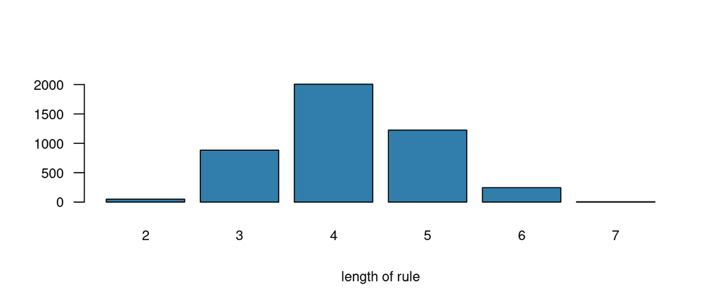

Length of the associate rules = LHS+RHS (products group)

```r
barplot(table(size(rules_groc_lvl2_new_3)), col = col_1, cex.axis = 0.8, cex.names = 0.8, cex.lab = 0.8, las = 1,
        xlab = 'length of rule')
```

```r
summary(rules_groc_lvl2_new_3)
```

```
## set of 4417 rules
##
## rule length distribution (lhs + rhs):sizes
##    2    3    4    5    6    7
##   50  884 2007 1225  246    5
##
##    Min. 1st Qu.  Median    Mean 3rd Qu.    Max.
##   2.000   4.000   4.000   4.169   5.000   7.000
##
## summary of quality measures:
##     support           confidence        coverage             lift
##  Min.   :0.003050   Min.   :0.5000   Min.   :0.003152   Min.   :1.129
##  1st Qu.:0.003559   1st Qu.:0.5541   1st Qu.:0.005592   1st Qu.:1.697
##  Median :0.004474   Median :0.6238   Median :0.007219   Median :1.899
##  Mean   :0.006637   Mean   :0.6523   Mean   :0.010585   Mean   :1.958
##  3rd Qu.:0.006711   3rd Qu.:0.7381   3rd Qu.:0.010676   3rd Qu.:2.149
##  Max.   :0.187697   Max.   :1.0000   Max.   :0.345501   Max.   :4.293
##      count
##  Min.   :  30.00
##  1st Qu.:  35.00
##  Median :  44.00
##  Mean   :  65.27
##  3rd Qu.:  66.00
##  Max.   :1846.00
##
## mining info:
##            data ntransactions support confidence
##  Groceries_lvl2          9835   0.003        0.5
```

PODSUMOWANIE

```r
inspect(sort(rules_groc_lvl2_new_3, by = 'lift')[1:10])
```

```
##      lhs                         rhs           support confidence    coverage     lift count
## [1]  {dairy produce,
##       fruit,
##       sausage,
##       vegetables,
##       vinegar/oils}           => {cheese}  0.003152008  0.5438596 0.005795628 4.292825    31
## [2]  {fruit,
##       sausage,
##       vegetables,
##       vinegar/oils}           => {cheese}  0.003457041  0.5151515 0.006710727 4.066224    34
## [3]  {bread and backed goods,
##       eggs,
##       fruit,
##       sausage}                => {cheese}  0.003253686  0.5079365 0.006405694 4.009274    32
## [4]  {dairy produce,
##       frozen foods,
##       fruit,
##       non-alc. drinks,
##       sausage}                => {cheese}  0.003558719  0.5000000 0.007117438 3.946629    35
## [5]  {bread and backed goods,
##       cheese,
##       chocolate,
##       fruit}                  => {sausage} 0.003863752  0.6333333 0.006100661 3.348835    38
## [6]  {bread and backed goods,
##       cheese,
##       frozen foods,
##       fruit}                  => {sausage} 0.004677173  0.6301370 0.007422471 3.331934    46
## [7]  {bread and backed goods,
##       cheese,
##       chocolate,
##       dairy produce,
##       non-alc. drinks}        => {sausage} 0.003253686  0.6274510 0.005185562 3.317731    32
## [8]  {bread and backed goods,
##       cheese,
##       dairy produce,
##       poultry}                => {sausage} 0.003050330  0.6250000 0.004880529 3.304772    30
## [9]  {bread and backed goods,
##       chocolate,
##       frozen foods,
##       non-alc. drinks}        => {sausage} 0.003050330  0.6250000 0.004880529 3.304772    30
## [10] {bread and backed goods,
##       cheese,
##       chocolate,
##       dairy produce,
##       fruit}                  => {sausage} 0.003152008  0.6200000 0.005083884 3.278333    31
```

Reguły o wartości lift = x ozancza, że elementy z LHS i RHS występują ze sobą x razy częściej w porównaniu do zakupów gdzie zakałada się, że nie mają ze sobą związku; tzn.

- produkty z grup produkty mleczne, owoce, kiełabsy, warzywa oraz ocet i oleje wraz z serami są 4,3 raza częściej kupowane razem niż osobno (dotyczy LHS i RHS) (reguła [1]),
- owoce, kiełabsy, warzywa oraz ocet i oleje wraz z serami są 4 razy częściej kupowane niż osobno (reguła [2]),
- pieczywo i wypieki, jajka, owoce i kiełbasy wraz z serami są 4 razy częściej kupowane niż osobno (reguła [3]).

```r
inspect(sort(rules_groc_lvl2_new_3, by = 'confidence')[1:10])
```

```
##      lhs                         rhs                 support confidence    coverage     lift count
## [1]  {chocolate,
##       fruit,
##       staple foods}           => {dairy produce} 0.003558719  1.0000000 0.003558719 2.257287    35
## [2]  {eggs,
##       fruit,
##       staple foods}           => {dairy produce} 0.003660397  0.9729730 0.003762074 2.196279    36
## [3]  {cheese,
##       eggs,
##       perfumery}              => {dairy produce} 0.003660397  0.9729730 0.003762074 2.196279    36
## [4]  {eggs,
##       fruit,
##       non-alc. drinks,
##       vinegar/oils}           => {dairy produce} 0.003457041  0.9714286 0.003558719 2.192793    34
## [5]  {frozen foods,
##       fruit,
##       non-alc. drinks,
##       staple foods}           => {dairy produce} 0.003152008  0.9687500 0.003253686 2.186747    31
## [6]  {frozen foods,
##       fruit,
##       non-alc. drinks,
##       vinegar/oils}           => {dairy produce} 0.003050330  0.9677419 0.003152008 2.184471    30
## [7]  {bread and backed goods,
##       cheese,
##       fruit,
##       non-alc. drinks,
##       perfumery}              => {dairy produce} 0.003050330  0.9677419 0.003152008 2.184471    30
## [8]  {bread and backed goods,
##       fruit,
##       pork,
##       sausage}                => {dairy produce} 0.004880529  0.9600000 0.005083884 2.166996    48
## [9]  {bread and backed goods,
##       cheese,
##       non-alc. drinks,
##       perfumery}              => {dairy produce} 0.004270463  0.9545455 0.004473818 2.154683    42
## [10] {bread and backed goods,
##       eggs,
##       fruit,
##       vinegar/oils}           => {dairy produce} 0.003863752  0.9500000 0.004067107 2.144423    38
```

Reguły o wartości pewności = x oznacza, że za każdym razem, gdy zakupiono produkty z LHS, produkty z RHS były kupowane x przypadków conf(X->Y) można intepretować jak prawdopodobieństwo warunkowe P(Y|X)), tzn.

- jeżeli zakupiono produkty z grup czekolady, owoce i podstawowe produkty (mąka, ryż, kasze) to w 100% transakcji zakupiono produkty mleczne (reguła [1]),
- jeżeli zakupiono produkty z grup jajka, owoce i podstawowe produkty (mąka, ryż, kasze) to w 97% transakcji zakupiono produkty mleczne (reguła [2]),
- jeżeli zakupiono produkty z grup sery, jajka i perfumeria to w 97% transakcji zakupiono produkty mleczne (reguła [3]).

Zwraca uwagę fakt, iż reguły powstały niekoniecznie z elementów częstych, w porównaniu do reguł z 1. podejścia i 2.podejścia - w zasadzie następnik jest ten sam (produkty mleczne); reguły mają bardzo wysokie zaufanie - powyżej 95%.

**UWAGA** ponieważ produkty mleczne występują w 44% transakcji - tworzą reguły o dużej pewności, gdy są w następniku.

```r
inspect(sort(rules_groc_lvl2_new_3, by = 'support')[1:10])
```

```
##      lhs                                    rhs                      support
## [1]  {bread and backed goods}            => {dairy produce}          0.18769700
## [2]  {vegetables}                        => {dairy produce}          0.17041179
## [3]  {fruit}                             => {dairy produce}          0.15638027
## [4]  {sausage}                           => {dairy produce}          0.10737163
## [5]  {sausage}                           => {bread and backed goods} 0.10360956
## [6]  {cheese}                            => {dairy produce}          0.08459583
## [7]  {bread and backed goods,vegetables} => {dairy produce}          0.08195221
## [8]  {fruit,vegetables}                  => {dairy produce}          0.07869853
## [9]  {dairy produce,fruit}               => {vegetables}             0.07869853
## [10] {bread and backed goods,fruit}      => {dairy produce}          0.07727504
##      confidence coverage  lift     count
## [1]  0.5432607  0.3455008 1.226295 1846
## [2]  0.6242086  0.2730046 1.409018 1676
## [3]  0.6277551  0.2491103 1.417024 1538
## [4]  0.5677419  0.1891205 1.281557 1056
## [5]  0.5478495  0.1891205 1.585668 1019
## [6]  0.6677368  0.1266904 1.507274  832
## [7]  0.7051619  0.1162176 1.591753  806
## [8]  0.7350427  0.1070666 1.659203  774
## [9]  0.5032510  0.1563803 1.843379  774
## [10] 0.7183365  0.1075750 1.621492  760
```

Reguła o wartości wsparcia względnego = x oznacza, że x transakcji zawiera wymienione w LHS i RHS produkty.

- reguła o wsparciu względnym 0,18 oznacza, iż w 18% transakcji występują produkty z działu produkty mleczne (reguła [1]),
- reguła o wspraciu względnym 0,17 oznacza, iż w 17% transakcji zawiera warzywa i produkty mleczne (reguła [2]).

Reguły powyższe - w następniku maja głównie element produkty mleczne, w poprzedniku zaś - elementy częste. Dla pierwszych 5 reguł zauważyć należy, że przy wysokim wsparciu względnym >10% reguły mają też stosunkowo duże zaufanie - w granicach 0.55-0.63.

# 4 PODSUMOWANIE

## 4.1 Podsumowanie dot. zbioru danych

najczęściej występujące w listach zakupowych produkty to:

```r
tab_freq[list_pop_products]
```

```
##       whole milk other vegetables       rolls/buns             soda
##        0.2555160        0.1934926        0.1839349        0.1743772
##           yogurt    bottled water  root vegetables   tropical fruit
##        0.1395018        0.1105236        0.1089985        0.1049314
```

najczęściej występujące grupy produktów (= działy sklepu) to:

```r
tab_freq_lvl2[list_pop_gr_products]
```

```
##          dairy produce bread and backed goods        non-alc. drinks
##              0.4430097              0.3455008              0.3179461
##             vegetables                  fruit                sausage
##              0.2730046              0.2491103              0.1891205
##                   beer                 cheese           frozen foods
##              0.1555669              0.1266904              0.1169293
##              chocolate
##              0.1087951
```

a produkty w częstych grupach produktów to:

```r
list_lvl2$`dairy produce`; list_lvl2$`bread and backed goods`
```

```
## [1] "whole milk"         "butter"             "curd"
## [4] "dessert"            "butter milk"        "yogurt"
## [7] "whipped/sour cream" "beverages"
```

```
## [1] "rolls/buns"          "white bread"         "brown bread"
## [4] "pastry"              "roll products "      "semi-finished bread"
## [7] "zwieback"
```

## 4.2 Podsumowanie dot. przeprowadzonych eksperymetów

Przeprowadzono trzy eksperymenty - niezależnie dla produktów i grup produktów - dla parametrów: 1. podejście support = 0.003, confidence = 0.2

2. podejście support = 0.03, confidence = 0.2
3. podejście support = 0.003, confidence = 0.5

Do dalszej analizy i ostatecznych wniosków wybrano zbiór reguł, które powstały w 3.podejściu, ze względu na wysoką wartość zaufania.

Analizując reguły o wysokiej wartości zaufania na poziomie produktów

```r
inspect(sort(rules_groc_new_3, by = 'confidence')[1:10])
```

```
##      lhs                     rhs                    support confidence    coverage     lift count
## [1]  {citrus fruit,
##       tropical fruit,
##       root vegetables,
##       whole milk}         => {other vegetables} 0.003152008  0.8857143 0.003558719 4.577509    31
## [2]  {root vegetables,
##       butter,
##       yogurt}             => {whole milk}       0.003050330  0.7894737 0.003863752 3.089723    30
## [3]  {citrus fruit,
##       tropical fruit,
##       root vegetables}    => {other vegetables} 0.004473818  0.7857143 0.005693950 4.060694    44
## [4]  {root vegetables,
##       other vegetables,
##       brown bread}        => {whole milk}       0.003152008  0.7750000 0.004067107 3.033078    31
## [5]  {onions,
##       butter}             => {whole milk}       0.003050330  0.7500000 0.004067107 2.935237    30
## [6]  {tropical fruit,
##       curd,
##       yogurt}             => {whole milk}       0.003965430  0.7500000 0.005287239 2.935237    39
## [7]  {curd,
##       domestic eggs}      => {whole milk}       0.004778851  0.7343750 0.006507372 2.874086    47
## [8]  {tropical fruit,
##       butter,
##       yogurt}             => {whole milk}       0.003355363  0.7333333 0.004575496 2.870009    33
## [9]  {tropical fruit,
##       root vegetables,
##       whipped/sour cream} => {other vegetables} 0.003355363  0.7333333 0.004575496 3.789981    33
## [10] {butter,
##       curd}               => {whole milk}       0.004880529  0.7164179 0.006812405 2.803808    48
```

analizowano uwzględniając równiez ich wsparcie:

```r
inspect(sort(rules_groc_new_3, by = 'support')[1:10])
```

```
##      lhs                                      rhs                support
## [1]  {other vegetables,yogurt}             => {whole milk}       0.02226741
## [2]  {tropical fruit,yogurt}               => {whole milk}       0.01514997
## [3]  {other vegetables,whipped/sour cream} => {whole milk}       0.01464159
## [4]  {root vegetables,yogurt}              => {whole milk}       0.01453991
## [5]  {pip fruit,other vegetables}          => {whole milk}       0.01352313
## [6]  {root vegetables,yogurt}              => {other vegetables} 0.01291307
## [7]  {root vegetables,rolls/buns}          => {whole milk}       0.01270971
## [8]  {other vegetables,domestic eggs}      => {whole milk}       0.01230300
## [9]  {tropical fruit,root vegetables}      => {other vegetables} 0.01230300
## [10] {root vegetables,rolls/buns}          => {other vegetables} 0.01220132
##      confidence coverage   lift     count
## [1]  0.5128806  0.04341637 2.007235 219
## [2]  0.5173611  0.02928317 2.024770 149
## [3]  0.5070423  0.02887646 1.984385 144
## [4]  0.5629921  0.02582613 2.203354 143
## [5]  0.5175097  0.02613116 2.025351 133
## [6]  0.5000000  0.02582613 2.584078 127
## [7]  0.5230126  0.02430097 2.046888 125
## [8]  0.5525114  0.02226741 2.162336 121
## [9]  0.5845411  0.02104728 3.020999 121
## [10] 0.5020921  0.02430097 2.594890 120
```

Pośród reguł posortowanych wg wartości wsparcia zależność jest jeżeli warzywa lub owoce oraz produkt z grupy produkty mleczne (jogurt lub bita śmietana i śmietana zwykła)to pełne mleko lub inne warzywa - są to reguły ze wsparciem względnym > 0,012 (wsparcie bezwzględne > 118) oraz z zaufaniem > 50% ( czyli 1 na 2 transakcje na pewno będą tak wyglądały ).

Wizualizacja wniosków

```
## Itemsets in Antecedent (LHS)
## [1] "{citrus fruit,tropical fruit,root vegetables,whole milk}"
## [2] "{root vegetables,butter,yogurt}"
## [3] "{citrus fruit,tropical fruit,root vegetables}"
## [4] "{root vegetables,other vegetables,brown bread}"
## [5] "{onions,butter}"
## [6] "{tropical fruit,curd,yogurt}"
## [7] "{curd,domestic eggs}"
## [8] "{tropical fruit,butter,yogurt}"
## [9] "{tropical fruit,root vegetables,whipped/sour cream}"
## Itemsets in Consequent (RHS)
## [1] "{whole milk}"       "{other vegetables}"
```

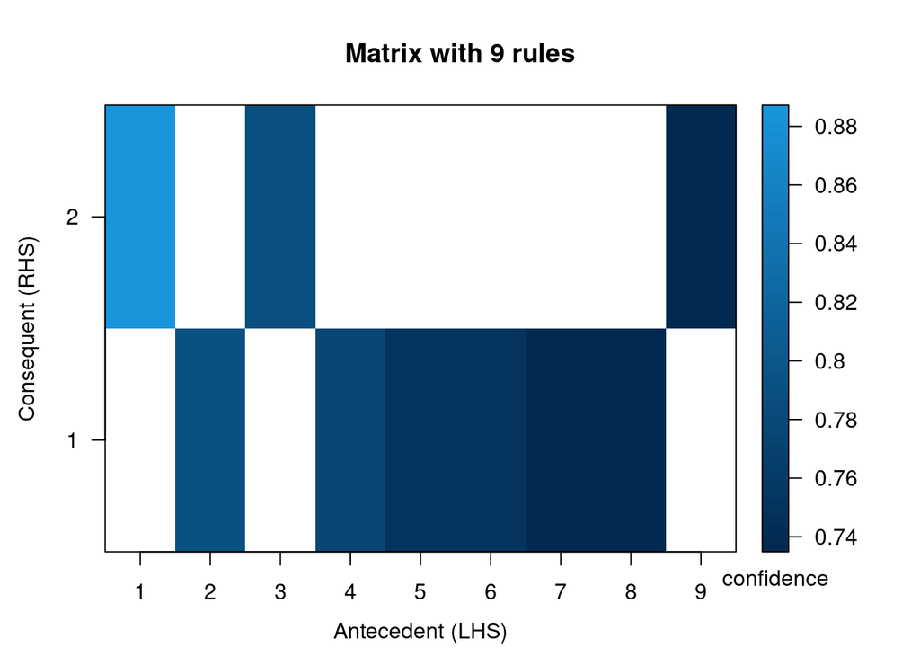

```r
plot(rules_groc_new_3[quality(rules_groc_new_3)$confidence > 0.73],
     method = 'matrix', shading = 'confidence', #main = '',
     control = list(col = colorRampPalette(c("#1995dc", "#022a50"))(50)))
```

Analizując reguły o wysokiej wartości zaufania na poziomie grup produktów

```r
inspect(sort(rules_groc_lvl2_new_3, by = 'confidence')[1:10])
```

```
##      lhs                         rhs                 support confidence    coverage     lift count
## [1]  {chocolate,
##       fruit,
##       staple foods}           => {dairy produce} 0.003558719  1.0000000 0.003558719 2.257287    35
## [2]  {eggs,
##       fruit,
##       staple foods}           => {dairy produce} 0.003660397  0.9729730 0.003762074 2.196279    36
## [3]  {cheese,
##       eggs,
##       perfumery}              => {dairy produce} 0.003660397  0.9729730 0.003762074 2.196279    36
## [4]  {eggs,
##       fruit,
##       non-alc. drinks,
##       vinegar/oils}           => {dairy produce} 0.003457041  0.9714286 0.003558719 2.192793    34
## [5]  {frozen foods,
##       fruit,
##       non-alc. drinks,
##       staple foods}           => {dairy produce} 0.003152008  0.9687500 0.003253686 2.186747    31
## [6]  {frozen foods,
##       fruit,
##       non-alc. drinks,
##       vinegar/oils}           => {dairy produce} 0.003050330  0.9677419 0.003152008 2.184471    30
## [7]  {bread and backed goods,
##       cheese,
##       fruit,
##       non-alc. drinks,
##       perfumery}              => {dairy produce} 0.003050330  0.9677419 0.003152008 2.184471    30
## [8]  {bread and backed goods,
##       fruit,
##       pork,
##       sausage}                => {dairy produce} 0.004880529  0.9600000 0.005083884 2.166996    48
## [9]  {bread and backed goods,
##       cheese,
##       non-alc. drinks,
##       perfumery}              => {dairy produce} 0.004270463  0.9545455 0.004473818 2.154683    42
## [10] {bread and backed goods,
##       eggs,
##       fruit,
##       vinegar/oils}           => {dairy produce} 0.003863752  0.9500000 0.004067107 2.144423    38
```

analizowano uwzględniając równiez ich wsparcie:

```r
inspect(sort(rules_groc_lvl2_new_3, by = 'support')[1:10])
```

```
##      lhs                                    rhs                      support
## [1]  {bread and backed goods}            => {dairy produce}          0.18769700
## [2]  {vegetables}                        => {dairy produce}          0.17041179
## [3]  {fruit}                             => {dairy produce}          0.15638027
## [4]  {sausage}                           => {dairy produce}          0.10737163
## [5]  {sausage}                           => {bread and backed goods} 0.10360956
## [6]  {cheese}                            => {dairy produce}          0.08459583
## [7]  {bread and backed goods,vegetables} => {dairy produce}          0.08195221
## [8]  {fruit,vegetables}                  => {dairy produce}          0.07869853
## [9]  {dairy produce,fruit}               => {vegetables}             0.07869853
## [10] {bread and backed goods,fruit}      => {dairy produce}          0.07727504
##      confidence coverage  lift     count
## [1]  0.5432607  0.3455008 1.226295 1846
## [2]  0.6242086  0.2730046 1.409018 1676
## [3]  0.6277551  0.2491103 1.417024 1538
## [4]  0.5677419  0.1891205 1.281557 1056
## [5]  0.5478495  0.1891205 1.585668 1019
## [6]  0.6677368  0.1266904 1.507274  832
## [7]  0.7051619  0.1162176 1.591753  806
## [8]  0.7350427  0.1070666 1.659203  774
## [9]  0.5032510  0.1563803 1.843379  774
## [10] 0.7183365  0.1075750 1.621492  760
```

Ciekawie wygląda reguła z 100% zaufaniem: jeżeli kupiono produkty z grup czekolady, owoce i podstawowe produkty (mąka, ryż, kasze) to produkty mleczne . Również ciekawe są kolejne reguły z zaufaniem graniczącym z 100% (>97%) jakkolwiek ich wsparcie względne jest pomijalnie małe - wynosi ~0.003-0.004 (wsparcie bezwzględne 30-38). Reguły te zbudowane sa z produktów rzadkich, acz bardzo silne wsparcie skłania do przyjrzenia się im dokładnie - szczególnei w kontekście ewentualnej arażacje poszczególnych działów względem siebie.

**CIEKAWOSTKI**

```r
inspect(sort(subset(rules_groc_lvl2_new_3, subset = lhs %in% 'dairy produce' & confidence > 0.80), by = 'confidence'))
```

```
##      lhs                            rhs                          support confidence    coverage     lift count
## [1]  {dairy produce,
##       frozen foods,
##       fruit,
##       poultry}                   => {vegetables}             0.004168785  0.8367347 0.004982206 3.064911    41
## [2]  {chocolate,
##       dairy produce,
##       non-alc. drinks,
##       sausage,
##       vegetables}                => {bread and backed goods} 0.003558719  0.8333333 0.004270463 2.411958    35
## [3]  {cheese,
##       dairy produce,
##       fruit,
##       staple foods}              => {vegetables}             0.003863752  0.8260870 0.004677173 3.025909    38
## [4]  {dairy produce,
##       non-alc. drinks,
##       poultry,
##       sausage}                   => {bread and backed goods} 0.004067107  0.8163265 0.004982206 2.362734    40
## [5]  {dairy produce,
##       poultry,
##       staple foods}              => {vegetables}             0.003965430  0.8125000 0.004880529 2.976141    39
## [6]  {chocolate,
##       dairy produce,
##       fruit,
##       non-alc. drinks,
##       sausage}                   => {bread and backed goods} 0.004372140  0.8113208 0.005388917 2.348246    43
## [7]  {beef,
##       dairy produce,
##       fruit,
##       pork}                      => {vegetables}             0.003457041  0.8095238 0.004270463 2.965239    34
## [8]  {dairy produce,
##       fruit,
##       non-alc. drinks,
##       sausage,
##       vinegar/oils}              => {bread and backed goods} 0.003863752  0.8085106 0.004778851 2.340112    38
## [9]  {chocolate,
##       dairy produce,
##       long-life bakery products,
##       sausage}                   => {bread and backed goods} 0.004270463  0.8076923 0.005287239 2.337744    42
## [10] {chocolate,
##       dairy produce,
##       non-alc. drinks,
##       sausage}                   => {bread and backed goods} 0.007015760  0.8023256 0.008744281 2.322211    69
```

jeżeli w lhs jest produkt z grupy ‘produktów mlecznych’ to z 80% w rhs będą ‘warzywa ’lub ’pieczywo i wypieki’

```r
inspect(sort(subset(rules_groc_lvl2_new_3, subset = lhs %in% 'bread and backed goods' & confidence > 0.80), by = 'confidence')[c(1, 64, 128, 194, 258)])
```

```
##     lhs                         rhs                 support confidence    coverage     lift count
## [1] {bread and backed goods,
##      cheese,
##      fruit,
##      non-alc. drinks,
##      perfumery}              => {dairy produce} 0.003050330  0.9677419 0.003152008 2.184471    30
## [2] {bread and backed goods,
##      cheese,
##      fruit,
##      non-alc. drinks,
##      vegetables}             => {dairy produce} 0.007320793  0.8888889 0.008235892 2.006477    72
## [3] {bread and backed goods,
##      fruit,
##      sweetener,
##      vegetables}             => {dairy produce} 0.003457041  0.8500000 0.004067107 1.918694    34
## [4] {bread and backed goods,
##      fruit,
##      non-alc. drinks,
##      perfumery,
##      vegetables}             => {dairy produce} 0.003863752  0.8260870 0.004677173 1.864715    38
## [5] {bread and backed goods,
##      perfumery,
##      vegetables}             => {dairy produce} 0.013523132  0.8012048 0.016878495 1.808549   133
```

jeżeli w lhs jest produkt z grupy ‘pieczywo i wypieki’ to z 80% w rhs będzie produkt z grupy ‘produkty mleczne’ (258 reguł - wybrane 5)

```r
inspect(sort(subset(rules_groc_lvl2_new_3, subset = lhs %in% 'vegetables' & confidence > 0.80), by = 'confidence')[c(1, 67, 134, 200, 267)])
```

```
##     lhs                            rhs                 support confidence    coverage     lift count
## [1] {frozen foods,
##      long-life bakery products,
##      non-alc. drinks,
##      vegetables}                => {dairy produce} 0.003660397  0.9473684 0.003863752 2.138483    36
## [2] {chocolate,
##      staple foods,
##      vegetables}                => {dairy produce} 0.003762074  0.8809524 0.004270463 1.988562    37
## [3] {bread and backed goods,
##      cheese,
##      fruit,
##      sausage,
##      vegetables}                => {dairy produce} 0.006914082  0.8500000 0.008134215 1.918694    68
## [4] {bread and backed goods,
##      fruit,
##      non-alc. drinks,
##      perfumery,
##      vegetables}                => {dairy produce} 0.003863752  0.8260870 0.004677173 1.864715    38
## [5] {bread and backed goods,
##      perfumery,
##      vegetables}                => {dairy produce} 0.013523132  0.8012048 0.016878495 1.808549   133
```

jeżeli w lhs jest produkt z grupy ‘warzywa’ to z 80% w rhs będzie produkt z grupy ‘produkty mleczne’ (267 reguł - wybrane 5)

**uwaga** dwa wyjątki - 186 i 258 (‘pieczywo i wypieki’)

```r
inspect(sort(subset(rules_groc_lvl2_new_3, subset = lhs %in% 'vegetables' & confidence > 0.80), by = 'confidence')[c(186, 258)])
```

```
##     lhs                  rhs                          support confidence    coverage     lift count
## [1] {chocolate,
##      dairy produce,
##      non-alc. drinks,
##      sausage,
##      vegetables}      => {bread and backed goods} 0.003558719  0.8333333 0.004270463 2.411958    35
## [2] {chocolate,
##      non-alc. drinks,
##      sausage,
##      vegetables}      => {bread and backed goods} 0.004168785  0.8039216 0.005185562 2.326830    41
```

```r
inspect(sort(subset(rules_groc_lvl2_new_3, subset = rhs %in% 'dairy produce'), by = 'confidence')[c(1, 359, 717, 1076, 1434)])
```

```
##     lhs                         rhs                 support confidence    coverage     lift count
## [1] {chocolate,
##      fruit,
##      staple foods}           => {dairy produce} 0.003558719  1.0000000 0.003558719 2.257287    35
## [2] {cheese,
##      fruit,
##      poultry}                => {dairy produce} 0.004880529  0.8421053 0.005795628 1.900873    48
## [3] {bread and backed goods,
##      non-alc. drinks,
##      snacks,
##      vegetables}             => {dairy produce} 0.003050330  0.7894737 0.003863752 1.782069    30
## [4] {bread and backed goods,
##      candy,
##      non-alc. drinks}        => {dairy produce} 0.005185562  0.7183099 0.007219115 1.621432    51
## [5] {bags,
##      chocolate}              => {dairy produce} 0.007422471  0.5000000 0.014844942 1.128644    73
```

‘produkty mleczne’ występują w rhs z pewnością ponad 50% (1434 reguły - 1/3 wszystkich utworzonych - powyżej wybrane 5)

```r
inspect(sort(subset(rules_groc_lvl2_new_3, subset = rhs %in% 'dairy produce'), by = 'count')[1:15])
```

```
##      lhs                         rhs                support confidence   coverage     lift count
## [1]  {bread and backed goods} => {dairy produce} 0.18769700  0.5432607 0.34550076 1.226295  1846
## [2]  {vegetables}             => {dairy produce} 0.17041179  0.6242086 0.27300458 1.409018  1676
## [3]  {fruit}                  => {dairy produce} 0.15638027  0.6277551 0.24911032 1.417024  1538
## [4]  {sausage}                => {dairy produce} 0.10737163  0.5677419 0.18912049 1.281557  1056
## [5]  {cheese}                 => {dairy produce} 0.08459583  0.6677368 0.12669039 1.507274   832
## [6]  {bread and backed goods,
##       vegetables}             => {dairy produce} 0.08195221  0.7051619 0.11621759 1.591753   806
## [7]  {fruit,
##       vegetables}             => {dairy produce} 0.07869853  0.7350427 0.10706660 1.659203   774
## [8]  {bread and backed goods,
##       fruit}                  => {dairy produce} 0.07727504  0.7183365 0.10757499 1.621492   760
## [9]  {bread and backed goods,
##       non-alc. drinks}        => {dairy produce} 0.07229283  0.5818331 0.12425013 1.313364   711
## [10] {frozen foods}           => {dairy produce} 0.06710727  0.5739130 0.11692933 1.295487   660
## [11] {non-alc. drinks,
##       vegetables}             => {dairy produce} 0.06446365  0.6817204 0.09456024 1.538839   634
## [12] {bread and backed goods,
##       sausage}                => {dairy produce} 0.06395526  0.6172718 0.10360956 1.393360   629
## [13] {fruit,
##       non-alc. drinks}        => {dairy produce} 0.06375191  0.6807818 0.09364514 1.536720   627
## [14] {vinegar/oils}           => {dairy produce} 0.05866802  0.6519774 0.08998475 1.471700   577
## [15] {sausage,
##       vegetables}             => {dairy produce} 0.05266904  0.6906667 0.07625826 1.559033   518
```

pierwsze trzy reguły są dwuelementowe i tworza je częste grupy produktów (jeżeli pieczywo i wypieki / warzywa / owoce to produkty mleczne) - reguły te mają zaufanie >54% oraz bardzo wysokie wsparcie >15,6%

```r
inspect(sort(subset(rules_groc_lvl2_new_3, subset = lhs %in% 'non-alc. drinks' & confidence > 0.80), by = 'support')[1:10])
```

```
##      lhs                         rhs                 support confidence   coverage     lift count
## [1]  {frozen foods,
##       fruit,
##       non-alc. drinks}        => {dairy produce} 0.015353330  0.8118280 0.01891205 1.832529   151
## [2]  {bread and backed goods,
##       non-alc. drinks,
##       vinegar/oils}           => {dairy produce} 0.014438231  0.8114286 0.01779359 1.831627   142
## [3]  {fruit,
##       non-alc. drinks,
##       vinegar/oils}           => {dairy produce} 0.012608033  0.8104575 0.01555669 1.829435   124
## [4]  {bread and backed goods,
##       cheese,
##       fruit,
##       non-alc. drinks}        => {dairy produce} 0.012201322  0.8510638 0.01433655 1.921095   120
## [5]  {cheese,
##       fruit,
##       non-alc. drinks,
##       vegetables}             => {dairy produce} 0.011286223  0.8345865 0.01352313 1.883901   111
## [6]  {bread and backed goods,
##       cheese,
##       non-alc. drinks,
##       vegetables}             => {dairy produce} 0.010981190  0.8780488 0.01250635 1.982008   108
## [7]  {eggs,
##       fruit,
##       non-alc. drinks}        => {dairy produce} 0.010269446  0.8559322 0.01199797 1.932085   101
## [8]  {non-alc. drinks,
##       staple foods,
##       vegetables}             => {dairy produce} 0.009659380  0.8119658 0.01189629 1.832840    95
## [9]  {cheese,
##       frozen foods,
##       non-alc. drinks}        => {dairy produce} 0.009049314  0.8240741 0.01098119 1.860172    89
## [10] {frozen foods,
##       fruit,
##       non-alc. drinks,
##       vegetables}             => {dairy produce} 0.009049314  0.8557692 0.01057448 1.931717    89
```

```r
inspect(sort(subset(rules_groc_lvl2_new_3, subset = rhs %in% 'non-alc. drinks' & confidence > 0.30), by = 'support')[1:10])
```

```
##      lhs                            rhs                  support confidence   coverage     lift count
## [1]  {beer,
##       dairy produce}             => {non-alc. drinks} 0.02379258  0.5176991 0.04595831 1.628261   234
## [2]  {bread and backed goods,
##       fruit,
##       sausage}                   => {non-alc. drinks} 0.02003050  0.5225464 0.03833249 1.643506   197
## [3]  {beer,
##       vegetables}                => {non-alc. drinks} 0.01718353  0.5044776 0.03406202 1.586676   169
## [4]  {fruit,
##       perfumery}                 => {non-alc. drinks} 0.01657346  0.5309446 0.03121505 1.669920   163
## [5]  {bread and backed goods,
##       dairy produce,
##       fruit,
##       sausage}                   => {non-alc. drinks} 0.01596340  0.5215947 0.03060498 1.640513   157
## [6]  {dairy produce,
##       frozen foods,
##       fruit}                     => {non-alc. drinks} 0.01535333  0.5000000 0.03070666 1.572594   151
## [7]  {beer,
##       fruit}                     => {non-alc. drinks} 0.01525165  0.5597015 0.02724962 1.760366   150
## [8]  {bread and backed goods,
##       chocolate,
##       dairy produce}             => {non-alc. drinks} 0.01494662  0.5157895 0.02897814 1.622254   147
## [9]  {bags,
##       sausage}                   => {non-alc. drinks} 0.01433655  0.5035714 0.02846975 1.583826   141
## [10] {bread and backed goods,
##       dairy produce,
##       long-life bakery products} => {non-alc. drinks} 0.01392984  0.5055351 0.02755465 1.590002   137
```

‘napoje niealkoholowe’ - mimo że sa częstą grupą produktów - tworzą reguły o bardzo małym wsparciu

```r
inspect(sort(subset(rules_groc_lvl2_new_3, subset = rhs %in% 'vegetables' & confidence > 0.75), by = 'support'))
```

```
##      lhs                         rhs              support confidence    coverage     lift count
## [1]  {dairy produce,
##       poultry,
##       sausage}                => {vegetables} 0.008845958  0.7909091 0.011184545 2.897054    87
## [2]  {bread and backed goods,
##       dairy produce,
##       fruit,
##       pork}                   => {vegetables} 0.006405694  0.7590361 0.008439248 2.780306    63
## [3]  {bread and backed goods,
##       dairy produce,
##       poultry,
##       sausage}                => {vegetables} 0.005795628  0.7702703 0.007524148 2.821456    57
## [4]  {bread and backed goods,
##       dairy produce,
##       non-alc. drinks,
##       pork}                   => {vegetables} 0.005185562  0.7611940 0.006812405 2.788210    51
## [5]  {dairy produce,
##       fruit,
##       pork,
##       sausage}                => {vegetables} 0.005083884  0.7575758 0.006710727 2.774956    50
## [6]  {poultry,
##       staple foods}           => {vegetables} 0.004982206  0.7777778 0.006405694 2.848955    49
## [7]  {dairy produce,
##       frozen foods,
##       fruit,
##       vinegar/oils}           => {vegetables} 0.004473818  0.7586207 0.005897306 2.778784    44
## [8]  {dairy produce,
##       eggs,
##       poultry}                => {vegetables} 0.004372140  0.7543860 0.005795628 2.763272    43
## [9]  {cheese,
##       fruit,
##       staple foods}           => {vegetables} 0.004168785  0.7884615 0.005287239 2.888089    41
## [10] {dairy produce,
##       frozen foods,
##       fruit,
##       poultry}                => {vegetables} 0.004168785  0.8367347 0.004982206 3.064911    41
## [11] {dairy produce,
##       poultry,
##       staple foods}           => {vegetables} 0.003965430  0.8125000 0.004880529 2.976141    39
## [12] {beef,
```

[output cut: 31 more lines]

```
##       vinegar/oils}           => {vegetables} 0.003253686  0.7619048 0.004270463 2.790813    32
## [22] {cheese,
##       sausage,
##       staple foods}           => {vegetables} 0.003253686  0.7619048 0.004270463 2.790813    32
## [23] {bread and backed goods,
##       frozen foods,
##       fruit,
##       vinegar/oils}           => {vegetables} 0.003253686  0.8000000 0.004067107 2.930354    32
## [24] {beef,
##       eggs,
##       sausage}                => {vegetables} 0.003152008  0.7560976 0.004168785 2.769542    31
## [25] {cheese,
##       dairy produce,
##       poultry,
##       sausage}                => {vegetables} 0.003050330  0.7692308 0.003965430 2.817648    30
```

jeżeli w rhs są ‘warzywa’ - reguły mają niskie wsparcie < 0,88%

```r
inspect(subset(subset(rules_groc_lvl2_new_3, items %in% 'dairy produce'), items %in% 'vegetables')[c(1, 586, 963)])
```

```
##     lhs                         rhs                          support confidence    coverage     lift count
## [1] {vegetables}             => {dairy produce}          0.170411795  0.6242086 0.273004575 1.409018  1676
## [2] {bread and backed goods,
##      frozen foods,
##      pork,
##      vegetables}             => {dairy produce}          0.003355363  0.8918919 0.003762074 2.013256    33
## [3] {beer,
##      dairy produce,
##      fruit,
##      vegetables}             => {bread and backed goods} 0.005185562  0.5930233 0.008744281 1.716417    51
```

17% (1676 z 9835) transakcji zawiera równocześnie ‘produkty mleczne’ i ‘warzywa’ (3 wybrane zasady)

```r
inspect(subset(subset(rules_groc_lvl2_new_3, items %in% 'bread and backed goods'), items %in% 'vegetables')[c(1, 456, 893)])
```

```
##     lhs                         rhs                          support confidence    coverage     lift count
## [1] {delicatessen,
##      vegetables}             => {bread and backed goods} 0.003355363  0.5789474 0.005795628 1.675676    33
## [2] {bread and backed goods,
##      eggs,
##      vegetables,
##      vinegar/oils}           => {dairy produce}          0.003355363  0.8918919 0.003762074 2.013256    33
## [3] {cheese,
##      dairy produce,
##      fruit,
##      non-alc. drinks,
##      sausage,
##      vegetables}             => {bread and backed goods} 0.003558719  0.7777778 0.004575496 2.251161    35
```

11% (1143 z 9835) transakcji równoczęsnie ‘pieczywo i bułeczki’ oraz ‘warzywa’ (3 wybrane zasady)

## 4.3 Podsumowanie końcowe

Z powyższych analiz wynika, że najczęściej kupowanym produktem jest ‘mleko pełne’, natomiast 1/3 reguł w następniku ma ‘produkty mleczne’; stąd zalecenia, aby **dział produktów mlecznych** był na samym końcu sklepu - tak, aby klient musiał przejść możliwie długa trasę. Mocną zależnością jest warzywa i owoce to zakupiono również pełne mleko’, stąd **dział z warzywami i owocami** powinny się znaleźć na poczatku sklepu (szczególnie, że reguły mające w następniku warzywa mają bardzo małe wsparcie).

W regułach opartych na częstych grupach produktów zaobserwoano silną zależność pomiędzy ‘produktami mlecznymi’ a ‘pieczywem i wypiekami’, co sugerowałoby, że **dział z pieczywme** powinien być zlokalizowany obok **działu z warzywami i owocami** - ewentualnie przedzielony jakimś działem rzadkim (zakupy impulsowe).

Szczególnie popularnym produktem są ‘bułki i bułeczki’ (18% transakcji), stąd zaleca się szczególnie skupić na rozwoju oferty tych produktów. Uwzględniając niezwykle duże wsparcie ‘mleka pełnego’ (25%) zaleca się dołożenie wszelkich starań, by go nie zabrakło w ofercie. Nadmienić należy, iż podobnie wysoką pozycje ma ‘jogurt’ (14%).

Warto zauważyć, iż o ile grupa produktów ‘napoje niealkoholowe’ jest częsta, nie wytwarz ona częstych reguł - bardzo małe wsparcie tej grupy sugerowałoby zlokalizowanie **działu z napojami** z boku sklepu.